# Analysing Sentences Backbone Communities

#### Top terms 2_11_1900-1919: political_economy, economic_science, marx, spiritual, science (1920-1929)

| Sentence | Title | Year | Journal | Authors | Similarity to HDSBSCAN Centroid |
| --- | --- | --- | --- | --- | --- |
| A previous article, in describing the reaction on religious thought of the economic movements of the sixteenth century, attempted to show how in England traditional doctrines of social morality were u… | [Religious Thought on Social and Economic Questions in the Sixteenth and Seventeenth Centuries](https://http://www.jstor.org/stable/1822446) | 1923 | Journal of Political Economy | R. H. Tawney | 0.834 |
| Religion had not yet consoled itself for the practical difficulty of applying its principles, by clasping the comfortable formula that for the dealings of economic life no moral principles exist. | [Religious Thought on Social and Economic Questions in the Sixteenth and Seventeenth Centuries](https://http://www.jstor.org/stable/1824578) | 1923 | Journal of Political Economy | R. H. Tawney | 0.834 |
| The assertion of economic liberty as a natural right comes at the close of a period in which, while religious phraseology remained and a religious interpretation of social institutions was, in some ca… | [Religious Thought on Social and Economic Questions in the Sixteenth and Seventeenth Centuries](https://http://www.jstor.org/stable/1824578) | 1923 | Journal of Political Economy | R. H. Tawney | 0.827 |
| But his words offer an appropriate text for a discussion of the change in the conception of the relation between religion and what would today be regarded as secular affairs, which took place in the s… | [Religious Thought on Social and Economic Questions in the Sixteenth and Seventeenth Centuries](https://http://www.jstor.org/stable/1824578) | 1923 | Journal of Political Economy | R. H. Tawney | 0.813 |
| ugust 1923 NUMBER 4 RELIGIOUS THOUGHT ON SOCIAL AND ECONOMIC QUESTIONS IN THE SIXTEENTH AND SEVENTEENTH CENTURIES I. | [Religious Thought on Social and Economic Questions in the Sixteenth and Seventeenth Centuries: I](https://http://www.jstor.org/stable/1861794) | 1923 | Journal of Political Economy | R. H. Tawney | 0.807 |
| A clearer interpretation than has ever been given of this whole side of their teachings would, I believe, throw new light upon their conceptions of economic laws, their ideals as to laissez-faire or n… | [Economics and the Idea of Natural Laws](https://http://www.jstor.org/stable/1885439) | 1929 | The Quarterly Journal of Economics | O. H. Taylor | 0.804 |
| The fundamental ideas, both transmitted to the sixteenth century, were two: that economic interests are subordinate to the real business of life, which is salvation, and that economic conduct is one a… | [Religious Thought on Social and Economic Questions in the Sixteenth and Seventeenth Centuries: I](https://http://www.jstor.org/stable/1861794) | 1923 | Journal of Political Economy | R. H. Tawney | 0.802 |
| It is not that they in any way abandon the claim of religion to moralize economic life, but that the economic life which they are concerned to moralize is one in which the main features of a commercia… | [Religious Thought on Social and Economic Questions in the Sixteenth and Seventeenth Centuries](https://http://www.jstor.org/stable/1822446) | 1923 | Journal of Political Economy | R. H. Tawney | 0.797 |
| It is implied that the bad social practice of the age was the inevitable expression of its religious innovations, that one order of social ethics was consciously abandoned and another introduced, and … | [Religious Thought on Social and Economic Questions in the Sixteenth and Seventeenth Centuries](https://http://www.jstor.org/stable/1824578) | 1923 | Journal of Political Economy | R. H. Tawney | 0.788 |
| I have called them “Religious Thought on Social and Economic Questions in the Sixteenth and Seventeenth Centuries,” not because there were not other currents which were of equal or greater significanc… | [Religious Thought on Social and Economic Questions in the Sixteenth and Seventeenth Centuries: I](https://http://www.jstor.org/stable/1861794) | 1923 | Journal of Political Economy | R. H. Tawney | 0.788 |

#### Top terms 2_12_1900-1919: workman, workmen, hours, employers, employer (1930-1939)

| Sentence | Title | Year | Journal | Authors | Similarity to HDSBSCAN Centroid |
| --- | --- | --- | --- | --- | --- |
| But these two statements are not yet sufficient to condemn the classical methods of mathematical economics as an arbitrary transgression of the limits of human reason. | [II](https://http://www.jstor.org/stable/2967553) | 1934 | The Review of Economic Studies | Harro Bernardelli | 0.788 |
| Economists have often expostulated over the excessive rationalism of the eighteenth century, and it is certainly true that mankind is not the perfect calculator of classical theory. | [Fifty Years’ Developments in Ideas of Human Nature and Motivation](https://http://www.jstor.org/stable/1807783) | 1936 | The American Economic Review | C. E. Ayres | 0.784 |
| This general principle applies with especial force to economics, if we grant that it is highly desirable to keep economics ” scientific.” | [“Economic Welfare”](https://http://www.jstor.org/stable/2548228) | 1930 | Economica | F. C. Benham | 0.775 |
| Now unfortunately economic theory for the most part consists of the unlovely and inanimate skeletons of economic controversies of the past. | [Review of Economic Text-Books for Use in Canadian High Schools](https://www.jstor.org/stable/10.2307/136556) | 1934 | Contributions to Canadian Economics | A. E. Gilroy, A. F. W. Plumptre | 0.759 |
| This not merely begs the question (to which we shall return) whether a precise definition of the subject-matter of economics is possible or necessary, but it makes no attempt to justify the definition… | [How Do We Want Economists to Behave?](https://http://www.jstor.org/stable/2223780) | 1932 | The Economic Journal | Lindley M. Fraser | 0.757 |
| The sterility of much ecohomic theory has been due, I think, to the attempt to amplify into a body of theory a single dominating principle, in terms of whiclh all economic phenomena might be interpret… | [The Theory of Economic Dynamics as Related to Industrial Instability](https://http://www.jstor.org/stable/1805658) | 1930 | The American Economic Review | Frank W. Taussig, Frederick C. Mills, F. B. Garver, Frank H. Knight, R. W. Souter, Lewis L. Lorwin, Mordecai Ezekiel | 0.753 |
| One may doubt, however, that the economic theorists of today will subscribe to this characterization of their general systems of economics. | [Equilibrium Economics and Business-Cycle Theory](https://http://www.jstor.org/stable/1885790) | 1930 | The Quarterly Journal of Economics | Simon Kuznets | 0.752 |
| On the contrary, the existing body of economic principles is the result of careful thinking based upon a few facts of general observation. | [The Scope and Definition of Economics](https://http://www.jstor.org/stable/1824178) | 1939 | Journal of Political Economy | Raymond T. Bye | 0.751 |
| This does not mean that we find them all equally well founded, or even that his central idea, namely, that in price movements lies the cause of economic progress, seems to us so solidly established as… | [François Simiand’s Theory of Economic Progress](https://http://www.jstor.org/stable/2967444) | 1938 | The Review of Economic Studies | Robert Marjolin, G. Jaffé, W. Jaffé | 0.748 |
| More and more the statement can be found that economics is but another name for politics, there being no line of demarcation between the two, and that the writing of history became scientific only whe… | [Marxian, Liberal, and Sociological Theories of Imperialism](https://http://www.jstor.org/stable/1823170) | 1931 | Journal of Political Economy | E. M. Winslow | 0.747 |

#### Top terms 2_11_1900-1919: political_economy, economic_science, marx, spiritual, science (1930-1939)

| Sentence | Title | Year | Journal | Authors | Similarity to HDSBSCAN Centroid |
| --- | --- | --- | --- | --- | --- |
| As long as wealth was confined to material goods the necessity of the hypothesis of the economic man, though unperceived by anyone before J. S. Mill, was a fact, since it is impossible to deny the inf… | [Nassau Senior’s Contribution to the Methodology of Economics](https://http://www.jstor.org/stable/2549222) | 1936 | Economica | Marian Bowley | 0.774 |
| In justice to Mill it must be remembered that he safeguarded himself by regarding his statement as a hypothesis, but Cairnes took Mill’s statement as a positive premnise, qualifying it by saying that … | [Nassau Senior’s Contribution to the Methodology of Economics](https://http://www.jstor.org/stable/2549222) | 1936 | Economica | Marian Bowley | 0.769 |
| For Adams believed that a large proportion of mankind is irrational and imprudent in respect to the preservation and acquisition of wealth; that but a small proportion possesses property whereas the v… | [Malthusianism In Late Eighteenth Century America](https://http://www.jstor.org/stable/1807805) | 1935 | The American Economic Review | J. J. Spengler | 0.757 |
| With Mill again the problem as to which line of conduct will yield “the greater portion of wealth” is not mentioned as existing, and his principle that men “naturally” prefer this to a smaller portion… | [Expectation and Rational Conduct](https://http://www.jstor.org/stable/41793308) | 1937 | Zeitschrift für Nationalökonomie / Journal of Economics | T. W. Hutchison | 0.754 |
| than a philosopher he did not share Adam Smith’s interest in the ethical significance of a labor theory of value, but when he came to work out the principles of his own economic system he was naturall… | [A Re-Interpretation of Ricardo on Value](https://http://www.jstor.org/stable/1883868) | 1935 | The Quarterly Journal of Economics | John M.Cassels | 0.743 |
| Like Cardozo, he believed that the increase of numbers, limited by the prudential check, tended to follow, not to precede, the growth of capital and subsistence to support it.80 Malthus would probably… | [The Early American Reaction to the Theory of Malthus](https://http://www.jstor.org/stable/1837254) | 1931 | Journal of Political Economy | George Johnson Cady | 0.739 |
| “12I He was confident (and offered as evidence the slow growth of the Norman population) that as man passed out of barbarism (where Malthus’ principle”is a fatal, inevitable law”) into civilization, t… | [French Population Theory Since 1800: I](https://http://www.jstor.org/stable/1824133) | 1936 | Journal of Political Economy | Joseph J. Spengler | 0.733 |
| After this impediment had been removed, it developed in a remarkable and even spectacular manner, which seemed to Adam Smith the exact consequence of ” giving Nature fair play in the pursuit of her en… | [New Light on Adam Smith](https://http://www.jstor.org/stable/2224878) | 1936 | The Economic Journal | W. R. Scott | 0.729 |
| Mill claims for himself not “the original conception, but only the elaboration” of the part played by the “law of reciprocal demand.” | [The Doctrine of Comparative Costs](https://http://www.jstor.org/stable/40415959) | 1932 | Weltwirtschaftliches Archiv | Jacob Viner | 0.727 |
| He recognized that the country as a whole needed laborers; the problem was one of selecting and properly distributing them.106 An excellent analysis of the premises underlying the theories of Malthus … | [The Early American Reaction to the Theory of Malthus](https://http://www.jstor.org/stable/1837254) | 1931 | Journal of Political Economy | George Johnson Cady | 0.726 |

| Sentence | Title | Year | Journal | Authors | Similarity to HDSBSCAN Centroid |
| --- | --- | --- | --- | --- | --- |
| But into everything that was not a theorem in the pure logic of economics the whole man and all the forces that conditioned him entered so unmistakably that it is more necessary than it usually is in … | [Vilfredo Pareto (1848-1923)](https://http://www.jstor.org/stable/1883096) | 1949 | The Quarterly Journal of Economics | Joseph A. Schumpeter | 0.782 |
| Now from a man who took that view of the nature and the function of economic theory, one might have expected a treatise very different from the Principles, one that could never have enjoyed widespread… | [Alfred Marshall’s Principles: A Semi-Centennial Appraisal](https://http://www.jstor.org/stable/356) | 1941 | The American Economic Review | Joseph A. Schumpeter | 0.781 |
| Given his premise that economics should explain reality, and given also his empiricist conception of science and his emphasis on change, he could not view the classical economics as other than unreali… | [Sociological Elements in Veblen’s Economic Theory](https://http://www.jstor.org/stable/1825050) | 1945 | Journal of Political Economy | Arthur K. Davis | 0.779 |
| 9 Finally, it must not be overlooked that without the simplifying assumption of the economic man and the rationality of his conduct, the classical economists could not have established their work on a… | [Rational Human Conduct and Modern Industrial Society](https://http://www.jstor.org/stable/1052713) | 1943 | Southern Economic Journal | Karl W. Kapp | 0.773 |
| He maintained that our intuitive knowledge of human nature was such that economics could start where physics stood after the discovery of the gravitational law and similar fundamentals.7 He maintained… | [A Neglected Point in the Training of Agricultural Economists](https://http://www.jstor.org/stable/1232629) | 1947 | Journal of Farm Economics | Howard E. Conklin | 0.770 |
| It will be recognized that economic theory in this sense is not equivalent to general economics. | [The Logical Foundations of Economic Research](https://http://www.jstor.org/stable/1232709) | 1949 | Journal of Farm Economics | Kenneth H. Parsons | 0.763 |
| So much the worse for the theories, to be sure; but it is an important if unpleasant reflection that so much of the advance in economic thought has been due to re-examination of foolish doctrine occas… | [Heimann’s History of Doctrine and Current Issues](https://http://www.jstor.org/stable/1827066) | 1946 | Journal of Political Economy | Frank H. Knight | 0.750 |
| It is, however, the philosophical basis of modern economics. | [Psychological Aspects of Economic Thought](https://http://www.jstor.org/stable/1826270) | 1949 | Journal of Political Economy | Walter A. Weisskopf | 0.749 |
| After declaring that the “economic principle” - the principle that “makes of economics an independent science” - had not yet been sufficiently well defined in relation to the principles of other scien… | [Croce and the Nature of Economic Science](https://http://www.jstor.org/stable/1884568) | 1945 | The Quarterly Journal of Economics | Giorgio Tagliacozzo | 0.749 |
| This is perhaps the main reason why an interpretation of the meaning of economic science can be derived from his philosophy. | [Croce and the Nature of Economic Science](https://http://www.jstor.org/stable/1884568) | 1945 | The Quarterly Journal of Economics | Giorgio Tagliacozzo | 0.749 |

#### Top terms 2_10_1900-1919: private_property, property, employees, laborer, institution (1940-1949)

| Sentence | Title | Year | Journal | Authors | Similarity to HDSBSCAN Centroid |
| --- | --- | --- | --- | --- | --- |
| Since most readers are familiar in a general way with what has been written about Smith, they will discover wherein the point of view of this effort differs from the standard interpretation, especiall… | [Adam Smith and the Economic Man](https://http://www.jstor.org/stable/1826047) | 1948 | Journal of Political Economy | William D. Grampp | 0.817 |
| His line of thought reminds me strongly of the following passages which we find in an early chapter of ” An Inquiry into the Nature and Causes of the Wealth of Nations, ” Adam Smith’s immortal work, w… | [SSU-MA CHIEN’S ECONOMIC OUTLOOK](https://www.jstor.org/stable/10.2307/43216842) | 1940 | Kyoto University Economic Review | Fumio Hozumi | 0.810 |
| Mill to formulate the Law of Markets, for more than a century a pillar of received economic theory.35 The Physiocrats differed from Smith and his successors: they did not suppose that continuity of ex… | [The Problem of Order in Economic Affairs](https://http://www.jstor.org/stable/1054269) | 1948 | Southern Economic Journal | Joseph J. Spengler | 0.781 |
| As Miss Bowley puts it: ” As long as wealth was confined to material goods, the necessity of the hypothesis of the economic man, though unperceived by any one before J. S. Mill, was a fact, since it i… | [The Welfare Significance of Productive Labour](https://http://www.jstor.org/stable/2967516) | 1943 | The Review of Economic Studies | Hla Myint | 0.780 |
| Smith’s opposition to nonempirical modes of reasoning extended even to a disparagement of formal logic.41 Since it may safely be assumed that Smith did not hold to a logical dichotomy of Naturwissensc… | [Adam Smith’s Empiricism and the Law of Nature: I](https://http://www.jstor.org/stable/1825483) | 1940 | Journal of Political Economy | Henry J. Bittermann | 0.771 |
| He did not suggest, however, that in such a hypothetical stationary state there would be underconsumption and underproduction because of oversaving I34 Smith’s discussion of parsimony, while not formu… | [The Physiocrats and Say’s Law of Markets. II](https://http://www.jstor.org/stable/1826905) | 1945 | Journal of Political Economy | Joseph J. Spengler | 0.770 |
| “I55 Granting then that Smith accepted some form of natural theology, the problem is resolved into a determination of its part in his ethical, and so of his normative economic, theories. | [Adam Smith’s Empiricism and the Law of Nature](https://http://www.jstor.org/stable/1825511) | 1940 | Journal of Political Economy | Henry J. Bittermann | 0.769 |
| The political doctrine of Smith does not depart from that of Hume in any important way, but it deserves separate mention because of the emphasis which utility receives and because of Smith’s specifica… | [On the Politics of the Classical Economists](https://http://www.jstor.org/stable/1883468) | 1948 | The Quarterly Journal of Economics | William D. Grampp | 0.767 |
| It is proposed in this essay to re-examine the question of Smith’s naturalism, to analyze his methodology in its bearing on the assumptions of natural law and natural theology, in order to determine t… | [Adam Smith’s Empiricism and the Law of Nature: I](https://http://www.jstor.org/stable/1825483) | 1940 | Journal of Political Economy | Henry J. Bittermann | 0.766 |
| Political Economy was concerned, such was Mill’s view, with Man solely as a being who desires to possess wealth, and who can make efforts to that end. | [Economics: Yesterday and To-morrow](https://http://www.jstor.org/stable/2226570) | 1949 | The Economic Journal | Alexander Gray | 0.764 |

#### Top terms 2_11_1900-1919: political_economy, economic_science, marx, spiritual, science (1950-1959)

| Sentence | Title | Year | Journal | Authors | Similarity to HDSBSCAN Centroid |
| --- | --- | --- | --- | --- | --- |
| Still this should not render us purblind to the fact that what he presented as a “matter-offact” inquiry into “brute” causation is substantially a critique of existing economic institutions and theori… | [Veblen and the Social Phenomenon of Capitalism](https://http://www.jstor.org/stable/1910777) | 1951 | The American Economic Review | Abram L. Harris | 0.791 |
| To deny any influence to economic analysis is to deny any role to reason in the formation by a sensible man of his system of ends. | [Schumpeter’s History of Economic Analysis](https://http://www.jstor.org/stable/1807709) | 1954 | The American Economic Review | Jacob Viner | 0.775 |
| However, what emerges from such a conviction is not the use of physical or biological analogies in economics. | [The Concept of Energy in Economics](https://http://www.jstor.org/stable/40433455) | 1954 | Weltwirtschaftliches Archiv | S. D. Zagoroff | 0.767 |
| No one would deny to economists the right to define their subject in any manner they wish, but little common sense was needed to under- | [The Influence of Keynesian Economics on Contemporary Thought](https://http://www.jstor.org/stable/1831578) | 1957 | The American Economic Review | Dudley Dillard | 0.762 |
| Now of course there cannot be an absolute restriction of economics to a study of just the pattern of related, changing economic quantities and nothing else. | [Schumpeter and Marx: Imperialism and Social Classes in the Schumpeterian System](https://http://www.jstor.org/stable/1882578) | 1951 | The Quarterly Journal of Economics | O. H. Taylor | 0.760 |
| This is shown by a perusal of his works, and he himself has declared to that effect.6) Accordingly, it will not be fair to adjudge his economic thought on the basis of his economic theory ; rather it … | [SOCIAL THOUGHT OF R. H. TAWNEY](https://www.jstor.org/stable/10.2307/43217075) | 1959 | Kyoto University Economic Review | Yuzo Deguchi | 0.760 |
| The influence of this operation on the thinking of contemporary economists, however, has not been obvious-a fact which leads one to the conclusion that it was not a strong influence. | [The Development of the Concept of “Automatic Stabilizers”](https://http://www.jstor.org/stable/2976652) | 1956 | The Journal of Finance | Norman F. Keiser | 0.755 |
| Thus economic theory does not by any means produce identical explanations and conclusions concerning economic events and processes. | [The Pragmatic Basis of Economic Theory](https://http://www.jstor.org/stable/137857) | 1950 | The Canadian Journal of Economics and Political Science / Revue canadienne d’Economique et de Science politique | H. Scott Gordon | 0.753 |
| But this was the nature of classical economics. | [The Macro and Micro Aspects of the Wealth of Nations](https://http://www.jstor.org/stable/1054159) | 1954 | Southern Economic Journal | John P. Henderson | 0.749 |
| Some students of the development of economic thought have even suggested that the various economic doctrines which have gained prominence were intended - deliberately or unconsciously - to rationalize… | [Prolegomena to a History of Economic Reasoning](https://http://www.jstor.org/stable/1879498) | 1951 | The Quarterly Journal of Economics | Karl Pribram | 0.749 |

#### Top terms 2_6_1900-1919: adam_smith, adam, smith, smith’s, adam_smith’s (1950-1959)

| Sentence | Title | Year | Journal | Authors | Similarity to HDSBSCAN Centroid |
| --- | --- | --- | --- | --- | --- |
| economics which Mill tried to defend, or rather the naturalistic economics, were never to be considered to have been based on a way of thinking peculiar to social sciences, because its fundamental sta… | [On Historical Research in Social Sciences](https://www.jstor.org/stable/10.2307/43217000) | 1952 | Kyoto University Economic Review | Yūzo Deguchi | 0.777 |
| At least that would appear to be the gist of the following statement from John Stuart Mill, a position from which latter-day economists have not been known to dissent. | [A Theory of the Social Origin of Factors of Production](https://http://www.jstor.org/stable/3484549) | 1955 | The American Journal of Economics and Sociology | David Hamilton | 0.775 |
| In Malthus the relation between the theory of production and that of distribution became weak, and that in John Stuart Mill the theory of production was detached and was treated as a simple technical … | [THE MEANING AND PROBLEMS OF THE MALTHUS-RICARDO STUDY](https://www.jstor.org/stable/10.2307/43217031) | 1955 | Kyoto University Economic Review | Seijirō KISHIMOTO | 0.770 |
| .. that there is no consistent medium between perfect freedom and entire free agency of capital and labour, and that principle which would regulate wages, profits, and the whole relations of life by a… | [The London Economist and the High Tide of Laissez Faire](https://http://www.jstor.org/stable/1825367) | 1955 | Journal of Political Economy | Scott Gordon | 0.768 |
| Perhaps Malthus felt that this theory gave further support to his belief that ” it is positively incorrect to state redundancy or cheapness of currency in any sense in which these terms can be fairly … | [The Origin of Ricardo’s Theory of Profits](https://http://www.jstor.org/stable/2550358) | 1954 | Economica | G. S. L. Tucker | 0.766 |
| rejected the theory of a value of labour in regard to the formation of value, but the labour considered by Malthus being a separate labour, he would have reached a standstill in accounting for a measu… | [MALTHUS’S THEORIES IN CLASSICAL ECONOMICS](https://www.jstor.org/stable/10.2307/43216933) | 1950 | Kyoto University Economic Review | Seijiro Kishimoto | 0.766 |
| “5 Malthus, in other words, having assumed that all money saved is quite literally invested, is obliged later on, when he tries to show the possibility of over-accumulation, either to deny his origina… | [Ricardo, Malthus and the Moderns](https://http://www.jstor.org/stable/1054047) | 1952 | Southern Economic Journal | David McCord Wright | 0.765 |
| This, however, indicates that Adam Smith did not really want to demote the labor theory of value by projecting it into the past; it shows that he considered the determination of economic values by lab… | [The Psychocultural Background of Adam Smith’s Theory of Value](https://http://www.jstor.org/stable/3484609) | 1952 | The American Journal of Economics and Sociology | Walter A. Weisskopf | 0.764 |
| Ricardo’s attention had been drawn to the significance of what he then called ” Mr. Mill’s principle ” at least as early as I84 when, in the formative period of his mature thought, he was arguing with… | [The Decline of Ricardian Economics in England](https://http://www.jstor.org/stable/2550179) | 1950 | Economica | Ronald L. Meek | 0.761 |
| This interpretation is perhaps strengthened by the fact that Malthus later put forward a very similar argument in his Principles of Political Economy (1820). | [The Origin of Ricardo’s Theory of Profits](https://http://www.jstor.org/stable/2550358) | 1954 | Economica | G. S. L. Tucker | 0.756 |

| Sentence | Title | Year | Journal | Authors | Similarity to HDSBSCAN Centroid |
| --- | --- | --- | --- | --- | --- |
| However, the nature of much basic economic theory is not directly evident from casual common sense reasoning. | [A Note on Quasi-Programming in Economic Principles Instruction](https://www.jstor.org/stable/10.2307/40472280) | 1965 | Nebraska Journal of Economics and Business | John H. Wicks | 0.810 |
| A tendency arose, partly unconscious, to avoid the impression that economic theorists bore the responsibility to make their assumptions as realistic as they could, given practical limitations in knowl… | [Friedman and Machlup on the Significance of Testing Economic Assumptions](https://http://www.jstor.org/stable/1828428) | 1965 | Journal of Political Economy | Jack Melitz | 0.800 |
| This, however, does not mean that economic theory as a whole is not valuable. | [Axioms of Economics and the Claim to Efficiency](https://http://www.jstor.org/stable/4223956) | 1968 | Journal of Economic Issues | Sherman Krupp | 0.778 |
| One school of thought holds that economic theories contain terms which upon close examination can be shown to lack any connection with factual or empirical reality. | [An Empirical Principle for Deductive Theory in Economics](https://http://www.jstor.org/stable/1055334) | 1967 | Southern Economic Journal | Robert G. Fabian | 0.776 |
| At times the attribution of policies to economic theory was dubious to say the least. | [History of Economic Doctrines and Economic History](https://http://www.jstor.org/stable/1823648) | 1969 | The American Economic Review | Alexander Gerschenkron | 0.773 |
| It might be supposed, even by economists who find the rationality assumption innocuous enough, that, if economics could have dispensed with this assumption, the epistemological foundations of the disc… | [Rational Action and Economic Theory](https://http://www.jstor.org/stable/1861734) | 1962 | Journal of Political Economy | Israel M. Kirzner | 0.773 |
| Yet to this principle certain economists take exception. | [Internal Economies](https://http://www.jstor.org/stable/2229795) | 1969 | The Economic Journal | Alec Nove | 0.769 |
| But besides this, the effort to generalize sometimes seems to be an end in itself.2 Were that not the case, hypotheses which only imply logically true statements about empirically observable phenomena… | [Some Reflections on the Relation between Economic Theory and Empirical Reality](https://http://www.jstor.org/stable/3439181) | 1967 | The Swedish Journal of Economics | Tõnu Puu | 0.762 |
| There is a danger, of course, that economic theory may lose something of its elegance in the process; but it can only gain in relevance. | [French Indicative Planning and the New Industrial State](https://http://www.jstor.org/stable/4224026) | 1969 | Journal of Economic Issues | Niles M. Hansen | 0.761 |
| It is clear then that economic theory if it is to offer genuine explanations of economic events and processes cannot consist entirely of analytic statements. | [Toward a Philosophy of Science for Agricultural Economic Research](https://http://www.jstor.org/stable/1235463) | 1961 | Journal of Farm Economics | A. N. Halter, H. H. Jack | 0.760 |

#### Top terms 2_12_1900-1919: workman, workmen, hours, employers, employer (1970-1979)

| Sentence | Title | Year | Journal | Authors | Similarity to HDSBSCAN Centroid |
| --- | --- | --- | --- | --- | --- |
| But even if it were assumed that the attainment of relatively unambiguous empirical results might be possible in economics, the latitude within which economic theory might be reoriented would seem res… | [Toward a Humanist Reconstruction of Economic Science](https://http://www.jstor.org/stable/4224777) | 1979 | Journal of Economic Issues | Jon D. Wisman | 0.794 |
| This latter assumption probably does not have broad appeal among economists. | [The Microeconomic Efficiency Argument for Socialism Revisited](https://http://www.jstor.org/stable/4224779) | 1979 | Journal of Economic Issues | James A. Yunker | 0.794 |
| It may be argued that any conception of explanation applicable to economics at large cannot be very definite. | [Explanation and Value in Economics](https://http://www.jstor.org/stable/4224885) | 1979 | Journal of Economic Issues | Timothy J. Brennan | 0.783 |
| This general theory-whether it be neoclassical economics, Marxism, or some other-is usually so much a part of the very thought processes that empirical disconfirmation of some particular hypothesis is… | [The Chicago School: Positivism or Ideal Type](https://http://www.jstor.org/stable/4224458) | 1975 | Journal of Economic Issues | Charles K. Wilber, Jon D. Wisman | 0.782 |
| Such an assumption is, for good reason, usually rejected by economists. | [Information, Entry, and Welfare: The Case for Collusion](https://http://www.jstor.org/stable/1808705) | 1979 | The American Economic Review | Donald Dewey | 0.774 |
| In general, it does not adequately reflect accepted economic theory. | [An Economic Analysis of the Webb-Pomerene Act](https://http://www.jstor.org/stable/725033) | 1970 | The Journal of Law & Economics | David A. Larson | 0.770 |
| It may also be argued, on much the same grounds, that the conventional economic wisdom is similarly limited. | [Environmental Control at the Crossroads](https://http://www.jstor.org/stable/4224063) | 1971 | Journal of Economic Issues | Harold Wolozin | 0.762 |
| In particular, economic theory in the traditional sense is not ruled out. | [The Role of Religious Ideas and the Use of Models in Max Weber’s Comparative Studies of Non-Capitalist Societies](https://http://www.jstor.org/stable/2116724) | 1970 | The Journal of Economic History | R. Stephen Warner | 0.759 |
| Moreover, the torturous extremes to which some scholars in the past went to rule as off limits to an economist qua economist any sort of “what ought to be” judgments were, I think, a little silly. | [Presidential Address: The Cause of Economic Literacy and The Business Economist](https://http://www.jstor.org/stable/23481278) | 1977 | Business Economics | A. Gilbert Heebner | 0.759 |
| It should be pointed out that this argument applies to economics as a science and not only to mathematical economics. | [Quantum Economics](https://www.jstor.org/stable/10.2307/25824883) | 1978 | Pakistan Economic and Social Review | ASGHAR QADIR | 0.758 |

| Sentence | Title | Year | Journal | Authors | Similarity to HDSBSCAN Centroid |
| --- | --- | --- | --- | --- | --- |
| which could be construed as rational only in the games of the theoretical economist. | [Competition, Contestability, and the Liner Shipping Industry (Comment and Rejoinder)](https://http://www.jstor.org/stable/20052882) | 1989 | Journal of Transport Economics and Policy | W. B. Jankowski, J. E. Davies | 0.798 |
| 8 A third view, related to the second, is that deciding to hold on to the rationality principle is in effect a decision to “do economics” as opposed to “doing” some other social science which might ex… | [Karl popper and economic methodology: A New Look](https://doi.org/10.1017/S0266267100001905) | 1985 | Economics and Philosophy | Hands D.W. | 0.788 |
| The implications which one can derive from such models will often be contradicted by the economic behaviour which one can observe in presumably rational people. | [The Three Markets for Private Insurance](https://www.jstor.org/stable/10.2307/41950007) | 1981 | The Geneva Papers on Risk and Insurance | Karl Borch | 0.784 |
| On the other hand, the “postulate of rationality” is the basis for almost all economic models. | [A Group Majority Voting Model of Public Good Provision](https://www.jstor.org/stable/10.2307/41105859) | 1987 | Social Choice and Welfare | R. B. Morton | 0.780 |
| On the other hand, economic theory is often unreliable as well. | [A Statistical Approach to Economic Forecasting](https://www.jstor.org/stable/10.2307/1391378) | 1986 | Journal of Business & Economic Statistics | Robert B. Litterman | 0.779 |
| Most economic theorising presumes rational behaviour, with actions resulting from the constrained optimisation of some objective function. | The determination of implicit preferences. Two Possible Approaches Compared | 1982 | European Economic Review | Ancot J. | 0.774 |
| If, however, the existence of a ‘correct’ model is not assumed, then economic theory and judgement play a more substantial, if sometimes informal, rôle. | [Keynesian model building and the rational expectations critique](https://http://www.jstor.org/stable/23596553) | 1981 | Cambridge Journal of Economics | Tony Lawson | 0.773 |
| There is literally an infinite number of assumptions that can be/the basis of an economic theory; rationality is only one. | [The Necessary Normative Context of Positive Economics](https://http://www.jstor.org/stable/4225070) | 1981 | Journal of Economic Issues | Richard B. McKenzie | 0.773 |
| This, however, is not something that can be developed into a vast deductive system as neoclassical economics does on the basis of its assumption about rational behavior. | [Market Power: The Missing Element in Keynesian Economics](https://http://www.jstor.org/stable/4226136) | 1989 | Journal of Economic Issues | Wallace C. Peterson | 0.771 |
| There is not always a careful statement of the economic significance of these assumptions. | Making sense of two-sided altruism | 1987 | Journal of Monetary Economics | Kimball M. | 0.770 |

| Sentence | Title | Year | Journal | Authors | Similarity to HDSBSCAN Centroid |
| --- | --- | --- | --- | --- | --- |
| Indeed this theory suggests that (a) for the standard problems and kinds of analysis in which economists trade, rationality is both insufficient and unnecessary and (b) that the term rational is gross… | [The Nature of Rational Choice and The Foundations of Statistics](https://http://www.jstor.org/stable/2663084) | 1991 | Oxford Economic Papers | Paul Anand | 0.828 |
| , in contrast, holds that ‘there is no general principle that prevents the creation of an economic theory based on hypotheses other than that of rationality’. | [A Critique of Instrumental Reason in Economics](https://doi.org/10.1017/S0266267100003229) | 1995 | Economics and Philosophy | Stewart H. | 0.821 |
| For economists habitually evaluate the rationality of actions, even actions having merely incidental economic aspects, according to their “economic efficiency.” (Unfortunately, the efficiency bias has… | The volunteer’s folly and socio-economic man: Some thoughts on altruism, rationality, and community | 1999 | Journal of Socio Economics | Knox T.M. | 0.820 |
| Some would postulate a specific variant of rationality, as most theories in economics do. | [Clarifying Popper](https://http://www.jstor.org/stable/2727352) | 1991 | Journal of Economic Literature | Bruce J. Caldwell | 0.806 |
| Economics ignores many aspects of behavior (details of thinking, social influences, limited rationality) in order to concentrate on two things: (i) simple formal assumptions about behavior (e.g. | The econometrics and behavioral economics of escalation of commitment: A re-examination of Staw and Hoang’s NBA data | 1999 | Journal of Economic Behavior and Organization | Camerer C.F. | 0.798 |
| Despite the probable unreality of the rationality assumption it can be defended on a number of grounds within the neoclassical framework. | [Belief: Its Role in Economic Thought and Action](https://http://www.jstor.org/stable/3487158) | 1993 | The American Journal of Economics and Sociology | J. Barkley Rosser, Jr. | 0.794 |
| Although these theories are partly rooted in economics, they do not assume that individuals have perfect knowledge or behave in perfectly rational ways. | Institutional determinants of saving: Implications for low-income households and public policy | 1999 | Journal of Socio Economics | Beverly S.G. | 0.793 |
| This reconsideration of their model is of interest not only to historians of economic thought. | Unanimity and majority rule: The calculus of consent reconsidered | 1998 | European Journal of Political Economy | Guttman J. | 0.792 |
| Economic theory generally takes it for granted that every economic decision-maker behaves as if he or she is rational, meaning he or she has well-defined preferences and sets marginal benefit equal to… | The role of gender in a non-cooperative game | 1991 | Journal of Economic Behavior and Organization | Mason C.F. | 0.790 |
| As much as economists would like to purge all normative considerations from their conception of rationality, this exercise merely empties the term “rationality” of its essential meaning. | The volunteer’s folly and socio-economic man: Some thoughts on altruism, rationality, and community | 1999 | Journal of Socio Economics | Knox T.M. | 0.786 |

| Sentence | Title | Year | Journal | Authors | Similarity to HDSBSCAN Centroid |
| --- | --- | --- | --- | --- | --- |
| This section discusses a number of empirical phenomena which many scholars have argued should be incorporated into our models of economic behavior. | [Taxing utility](https://doi.org/10.1016/j.socec.2005.12.001) | 2006 | Journal of Socio Economics | Chorvat T. | 0.843 |
| Economics contains its own standards for deciding good arguments from bad, for telling an important fact from an unimportant one, or a true explanation from one which is false—and not because of metho… | Normative behavioral economics | 2003 | Journal of Socio Economics | Berg N. | 0.830 |
| The approach we follow may have applications in the understanding of several economic phenomena. | [Bilateral mobility in dualistic models](https://doi.org/10.1016/j.econmod.2007.07.002) | 2008 | Economic Modelling | Martins A.P. | 0.830 |
| This organization reflects the goal of investigating psychological phenomena as they bear on economics, and hence to extract from this research formulations of alternative formal assumptions that stri… | A perspective on psychology and economics | 2002 | European Economic Review | Rabin M. | 0.828 |
| However, “while this model of individual behavior dominates contemporary economic analysis there is a long history among economists of questioning its behavioral validity and seeking alternatives” (Mc… | [Do emotions matter? Coherent preferences under anchoring and emotional effects](https://doi.org/10.1016/j.ecolecon.2007.11.005) | 2008 | Ecological Economics | Araña J.E. | 0.827 |
| Although potentially any economic theory can be absorbed (Dacey, 1976), the way a theory gets absorbed may differ from case to case, depending on its formulation, its accessibility, its understanding,… | [On the absorbability of informational cascades in the laboratory](https://doi.org/10.1016/j.socec.2009.06.014) | 2009 | Journal of Socio Economics | Morone A. | 0.827 |
| A traditional economist might reason in the following way. | Latent entrepreneurship across nations | 2001 | European Economic Review | Blanchflower D.G. | 0.824 |
| Interestingly, this work drew upon a number of conceptual and theoretical developments in economics and other related disciplines. | [Mineral economics: Overview of a discipline](https://doi.org/10.1016/j.resourpol.2008.01.003) | 2008 | Resources Policy | Gordon R.L. | 0.824 |
| In the economic literature, there exist two basic approaches to this conceptual difficulty that are relevant for our discussion. | [Global sunspots in OLG models. Theory and computational analysis](https://doi.org/10.1016/j.jmacro.2005.10.003) | 2006 | Journal of Macroeconomics | Gazzola G. | 0.822 |
| In the economic literature, there exist two basic approaches to this conceptual difficulty that are relevant for our discussion. | [Backward dynamics in economics. The inverse limit approach](https://doi.org/10.1016/j.jedc.2006.04.010) | 2007 | Journal of Economic Dynamics and Control | Medio A. | 0.822 |

### Top articles (most sentences) of the backbone cluster

| Title | Year | Journal | Authors | Number sentences | Words Similarity |
| --- | --- | --- | --- | --- | --- |
| [Classical and neoclassical conceptions of rationality-Findings of an exploratory survey](https://doi.org/10.1016/j.socec.2006.12.053) | 2008 | Journal of Socio Economics | Zafirovski M. | 125 | 0.668 |
| The arrival of behavioral economics: From Michigan, or the Carnegie School in the 1950s and the early 1960s? | 2003 | Journal of Socio Economics | Hosseini H. | 57 | 0.579 |
| A perspective on psychology and economics | 2002 | European Economic Review | Rabin M. | 50 | 0.576 |
| Normative behavioral economics | 2003 | Journal of Socio Economics | Berg N. | 44 | 0.582 |
| [In search of the economic self](https://doi.org/10.1016/j.socec.2005.07.010) | 2005 | Journal of Socio Economics | Lea S. | 43 | 0.570 |
| The individual in economic analysis: Toward psychology of economic behavior | 2002 | Journal of Socio Economics | Wolozin H. | 29 | 0.589 |
| [Economics and the Idea of Jus Naturale](https://http://www.jstor.org/stable/1885248) | 1930 | The Quarterly Journal of Economics | O. H. Taylor | 27 | 0.554 |
| [Mainstream economics, heterodoxy and academic exclusion: A review essay](https://doi.org/10.1016/j.ejpoleco.2004.06.003) | 2004 | European Journal of Political Economy | Schiffman D.A. | 27 | 0.558 |
| A socio-economic approach to market transactions | 1999 | Journal of Socio Economics | Zafirovski M. | 23 | 0.613 |
| [What is behavioral economics?](https://doi.org/10.1016/j.socec.2006.12.007) | 2007 | Journal of Socio Economics | Tomer J.F. | 23 | 0.576 |
| [Selfishness, cooperation, the evolutionary point of view and its implications for economics](https://doi.org/10.1016/j.ecolecon.2007.10.003) | 2009 | Ecological Economics | Pieńkowski D. | 23 | 0.572 |
| The volunteer’s folly and socio-economic man: Some thoughts on altruism, rationality, and community | 1999 | Journal of Socio Economics | Knox T.M. | 22 | 0.663 |
| [Beyond the rationality of economic man, toward the true rationality of human man](https://doi.org/10.1016/j.socec.2008.05.001) | 2008 | Journal of Socio Economics | Tomer J. | 21 | 0.684 |
| [Adam Smith and Laissez Faire](https://http://www.jstor.org/stable/1823421) | 1927 | Journal of Political Economy | Jacob Viner | 20 | 0.549 |
| Socio-economics and rational choice theory: Specification of their relations | 1998 | Journal of Socio Economics | Zafirovski M. | 20 | 0.592 |

### Top articles (most sentences) of the cluster for each time window

#### Top articles for 2_11_1900-1919: political_economy, economic_science, marx, spiritual, science (1900-1919)

| Title | Year | Journal | Authors | Number sentences | Words Similarity |
| --- | --- | --- | --- | --- | --- |
| [Hours of Labour](https://http://www.jstor.org/stable/2221102) | 1909 | The Economic Journal | S. J. Chapman | 9 | 0.540 |
| [The Development of Ricardo’s Theory of Value](https://http://www.jstor.org/stable/1882412) | 1904 | The Quarterly Journal of Economics | Jacob H. Hollander | 6 | 0.568 |
| [The Present Legal Status of Organized Labor in the United States](https://http://www.jstor.org/stable/1817541) | 1905 | Journal of Political Economy | Lindley D. Clark | 4 | 0.532 |
| [The Trade-Union Point of View](https://http://www.jstor.org/stable/1819493) | 1907 | Journal of Political Economy | Robert F. Hoxie | 4 | 0.561 |
| [The Report of the Royal Commission on Trade Disputes](https://http://www.jstor.org/stable/2221278) | 1906 | The Economic Journal | W. M. Geldart | 4 | 0.538 |
| [The Economic Theory of a Legal Minimum Wage](https://http://www.jstor.org/stable/1820545) | 1912 | Journal of Political Economy | Sidney Webb | 3 | 0.539 |
| [The Nature of Interest and the Causes of Its Fluctuations](https://http://www.jstor.org/stable/1884035) | 1917 | The Quarterly Journal of Economics | A. F. McGoun | 3 | 0.547 |
| [Wage Theory and Theories](https://http://www.jstor.org/stable/1884735) | 1919 | The Quarterly Journal of Economics | H. J. Davenport | 3 | 0.553 |
| [American Shoemakers, 1648-1895: A Sketch of Industrial Evolution](https://http://www.jstor.org/stable/1886057) | 1909 | The Quarterly Journal of Economics | John R. Commons | 3 | 0.554 |
| [The Assessment of Wages in England by the Justices of the Peace](https://www.jstor.org/stable/10.2307/20724757) | 1913 | Vierteljahrschrift für Sozial- und Wirtschaftsgeschichte | R. H. Tawney | 3 | 0.528 |

#### Top articles for 2_6_1900-1919: adam_smith, adam, smith, smith’s, adam_smith’s (1900-1919)

| Title | Year | Journal | Authors | Number sentences | Words Similarity |
| --- | --- | --- | --- | --- | --- |
| [Some Problems of Logical Method in Political Economy](https://http://www.jstor.org/stable/1819612) | 1917 | Journal of Political Economy | J. Viner | 4 | 0.584 |
| [The Early Propagandist Movement in English Population Theory](https://http://www.jstor.org/stable/1814928) | 1911 | The American Economic Review | James A. Field | 2 | 0.590 |
| [The Economics of John Stuart Mill](https://http://www.jstor.org/stable/1820347) | 1911 | Journal of Political Economy | James Bonar | 2 | 0.530 |
| [The Place of Value Theory in Economics: I](https://http://www.jstor.org/stable/1821866) | 1918 | Journal of Political Economy | Walton H. Hamilton | 2 | 0.552 |
| [The Rationality of Economic Activity: I](https://http://www.jstor.org/stable/1829775) | 1910 | Journal of Political Economy | Wesley C. Mitchell | 2 | 0.607 |
| [The Doctrine of the Distribution of Maintenance and Some of its Applications](https://http://www.jstor.org/stable/1884075) | 1904 | The Quarterly Journal of Economics | Charles W. Mixter | 2 | 0.579 |
| [The Subjective Element in the First Principles of Taxation](https://http://www.jstor.org/stable/1885206) | 1910 | The Quarterly Journal of Economics | F. Y. Edgeworth | 2 | 0.576 |
| [Social Productivity Versus Private Acquisition](https://http://www.jstor.org/stable/1885826) | 1910 | The Quarterly Journal of Economics | H. J. Davenport | 2 | 0.572 |
| [The Use and Abuse of Authority in Economics](https://http://www.jstor.org/stable/2221321) | 1903 | The Economic Journal | J. S. Nicholson | 2 | 0.554 |
| [The Incidence of Some land Taxes and the Dispersion of Differential Advantages](https://http://www.jstor.org/stable/2221969) | 1912 | The Economic Journal | S. J. Chapman | 2 | 0.545 |

#### Top articles for 2_10_1900-1919: private_property, property, employees, laborer, institution (1900-1919)

| Title | Year | Journal | Authors | Number sentences | Words Similarity |
| --- | --- | --- | --- | --- | --- |
| [The Theory of Value before Adam Smith](https://www.jstor.org/stable/10.2307/2485740) | 1901 | Publications of the American Economic Association | Hannah Robie Sewall | 6 | 0.570 |
| [The Place of Value Theory in Economics: I](https://http://www.jstor.org/stable/1821866) | 1918 | Journal of Political Economy | Walton H. Hamilton | 5 | 0.579 |
| [Some Problems of Logical Method in Political Economy](https://http://www.jstor.org/stable/1819612) | 1917 | Journal of Political Economy | J. Viner | 4 | 0.542 |
| [The Place of Value Theory in Economics: II](https://http://www.jstor.org/stable/1822591) | 1918 | Journal of Political Economy | Walton H. Hamilton | 4 | 0.567 |
| [The Socialist Economics of Karl Marx and His Followers](https://http://www.jstor.org/stable/1883435) | 1907 | The Quarterly Journal of Economics | Thorstein Veblen | 4 | 0.549 |
| [Jevon’s Economic Work](https://http://www.jstor.org/stable/2221414) | 1905 | The Economic Journal | Philip H. Wicksteed | 4 | 0.559 |
| [The Present State of the Theory of Distribution](https://www.jstor.org/stable/10.2307/2999963) | 1906 | Publications of the American Economic Association | Jacob H. Hollander | 4 | 0.563 |
| [The Work and Influence of Ricardo](https://http://www.jstor.org/stable/1814915) | 1911 | The American Economic Review | Jacob H. Hollander | 3 | 0.545 |
| [The Development of Hoxie’s Economics](https://http://www.jstor.org/stable/1817658) | 1916 | Journal of Political Economy | Walton H. Hamilton | 3 | 0.571 |
| [The Function and Problems of Economic Theory](https://http://www.jstor.org/stable/1820787) | 1918 | Journal of Political Economy | C. E. Ayres | 3 | 0.568 |

| Title | Year | Journal | Authors | Number sentences | Words Similarity |
| --- | --- | --- | --- | --- | --- |
| [Property, Philosophically and Religiously Regarded](https://http://www.jstor.org/stable/2222024) | 1914 | The Economic Journal | William Kennedy | 8 | 0.545 |
| [Economics and the Law: Annual Address of the President](https://http://www.jstor.org/stable/1810777) | 1915 | The American Economic Review | John H. Gray | 5 | 0.559 |
| [The Limitations of Marginal Utility](https://http://www.jstor.org/stable/1822146) | 1909 | Journal of Political Economy | Thorstein Veblen | 4 | 0.558 |
| [The Economics of Henry George’s “Progress and Poverty”](https://http://www.jstor.org/stable/1820687) | 1910 | Journal of Political Economy | Edgar H. Johnson | 3 | 0.552 |
| [The Adjustment of Crop Statistics: III](https://http://www.jstor.org/stable/1819313) | 1903 | Journal of Political Economy | H. Parker Willis | 2 | 0.579 |
| [The Economic Function of the Common Law](https://http://www.jstor.org/stable/1820903) | 1918 | Journal of Political Economy | Homer Hoyt | 2 | 0.550 |
| [Marginal Utility and Marginal Disutility as Ultimate Standards of Value](https://http://www.jstor.org/stable/1883442) | 1913 | The Quarterly Journal of Economics | Charles E. Persons | 2 | 0.559 |
| [The Negro in Africa and America](https://www.jstor.org/stable/10.2307/2485874) | 1902 | Publications of the American Economic Association | Joseph Alexander Tillinghast | 2 | 0.549 |
| [Theoretical Issues in the Single Tax](https://http://www.jstor.org/stable/1814350) | 1917 | The American Economic Review | H. J. Davenport | 1 | 0.522 |
| [The Extent and the Significance of the Unearned Increment](https://http://www.jstor.org/stable/1814938) | 1911 | The American Economic Review | H. J. Davenport | 1 | 0.542 |

| Title | Year | Journal | Authors | Number sentences | Words Similarity |
| --- | --- | --- | --- | --- | --- |
| [Ricardo’s Criticisms of Adam Smith](https://http://www.jstor.org/stable/1883798) | 1912 | The Quarterly Journal of Economics | Robert A. MacDonald | 6 | 0.548 |
| [The Study of Economic History](https://http://www.jstor.org/stable/2221137) | 1906 | The Economic Journal | L. L. Price | 4 | 0.549 |
| [Free Trade and Protection](https://http://www.jstor.org/stable/2956894) | 1902 | The Economic Journal | L. L. Price | 4 | 0.552 |
| [The Function and Problems of Economic Theory](https://http://www.jstor.org/stable/1820787) | 1918 | Journal of Political Economy | C. E. Ayres | 3 | 0.563 |
| [Cost History and Cost Theory](https://http://www.jstor.org/stable/1819503) | 1905 | Journal of Political Economy | H. J. Davenport | 2 | 0.516 |
| [The Development of Ricardo’s Theory of Value](https://http://www.jstor.org/stable/1882412) | 1904 | The Quarterly Journal of Economics | Jacob H. Hollander | 2 | 0.559 |
| [Petty’s Place in the History of Economic Theory](https://http://www.jstor.org/stable/1882563) | 1900 | The Quarterly Journal of Economics | Charles H. Hull | 2 | 0.558 |
| [The Development of the Theory of Money from Adam Smith to David Ricardo](https://http://www.jstor.org/stable/1883613) | 1911 | The Quarterly Journal of Economics | Jacob H. Hollander | 2 | 0.523 |
| [The Fundamental Notion of Capital, Once More](https://http://www.jstor.org/stable/1884864) | 1904 | The Quarterly Journal of Economics | Charles A. Tuttle | 2 | 0.558 |
| [On Some Neglected British Economists](https://http://www.jstor.org/stable/2221519) | 1903 | The Economic Journal | Edwin R. A. Seligman | 2 | 0.580 |

#### Top articles for 2_10_1900-1919: private_property, property, employees, laborer, institution (1920-1929)

| Title | Year | Journal | Authors | Number sentences | Words Similarity |
| --- | --- | --- | --- | --- | --- |
| [Issues in Economic Theory: an Attempt to Clarify](https://http://www.jstor.org/stable/1884782) | 1928 | The Quarterly Journal of Economics | Paul T. Homan | 13 | 0.550 |
| [Economics and the Idea of Natural Laws](https://http://www.jstor.org/stable/1885439) | 1929 | The Quarterly Journal of Economics | O. H. Taylor | 11 | 0.561 |
| [John Bates Clark: Earlier and Later Phases of his Work](https://http://www.jstor.org/stable/1885364) | 1927 | The Quarterly Journal of Economics | Paul T. Homan | 10 | 0.546 |
| [The Trend of Economics, as seen by Some American Economists](https://http://www.jstor.org/stable/1884871) | 1925 | The Quarterly Journal of Economics | Allyn A. Young | 9 | 0.561 |
| [English Political Economy](https://http://www.jstor.org/stable/2548381) | 1928 | Economica | Allyn A. Young | 8 | 0.570 |
| [The Impasse in Economic Theory](https://http://www.jstor.org/stable/1822132) | 1927 | Journal of Political Economy | Paul T. Homan | 6 | 0.588 |
| [Human Nature in Economic Theory](https://http://www.jstor.org/stable/1822708) | 1922 | Journal of Political Economy | Rexford G. Tugwell | 6 | 0.587 |
| [The Emancipation of Economics](https://http://www.jstor.org/stable/1809282) | 1924 | The American Economic Review | Lawrence K. Frank | 5 | 0.534 |
| [“Capitalism” in Recent German Literature: Sombart and Weber (Concluded)](https://http://www.jstor.org/stable/1822319) | 1929 | Journal of Political Economy | Talcott Parsons | 5 | 0.541 |
| [Economic Theory and Economic History](https://http://www.jstor.org/stable/2589870) | 1929 | The Economic History Review | Werner Sombart | 5 | 0.535 |

| Title | Year | Journal | Authors | Number sentences | Words Similarity |
| --- | --- | --- | --- | --- | --- |
| [The Doctrine of Comparative Cost](https://http://www.jstor.org/stable/1885553) | 1926 | The Quarterly Journal of Economics | Edward S. Mason | 7 | 0.547 |
| [Part I: What Can A Man Afford?](https://http://www.jstor.org/stable/1807356) | 1921 | The American Economic Review | Paul Douglas, Dorothy Douglas | 5 | 0.529 |
| [Employees’ Representation in Management of Industry](https://http://www.jstor.org/stable/1811888) | 1920 | The American Economic Review | Royal Meeker | 4 | 0.520 |
| [Industrial Morale](https://http://www.jstor.org/stable/1883569) | 1920 | The Quarterly Journal of Economics | Sumner H. Slichter | 4 | 0.526 |
| [The Ethics of Competition](https://http://www.jstor.org/stable/1884053) | 1923 | The Quarterly Journal of Economics | Frank H. Knight | 4 | 0.580 |
| [Rationalisation of Industry](https://http://www.jstor.org/stable/2223585) | 1927 | The Economic Journal | D. H. MacGregor | 4 | 0.571 |
| [Labor Supply and Labor Effort](https://http://www.jstor.org/stable/1815280) | 1925 | The American Economic Review | Elliott Dunlap Smith | 3 | 0.518 |
| [A Theory of the Rate of Wages](https://http://www.jstor.org/stable/1884753) | 1922 | The Quarterly Journal of Economics | Walton H. Hamilton | 3 | 0.545 |
| [The Nature and Fundamental Elements of Costs](https://http://www.jstor.org/stable/1885552) | 1926 | The Quarterly Journal of Economics | Raymond T. Bye | 3 | 0.517 |
| [The Meaning of Wages](https://http://www.jstor.org/stable/2222974) | 1925 | The Economic Journal | Lynda Grier | 3 | 0.534 |

#### Top articles for 2_6_1900-1919: adam_smith, adam, smith, smith’s, adam_smith’s (1920-1929)

| Title | Year | Journal | Authors | Number sentences | Words Similarity |
| --- | --- | --- | --- | --- | --- |
| [Adam Smith and Laissez Faire](https://http://www.jstor.org/stable/1823421) | 1927 | Journal of Political Economy | Jacob Viner | 15 | 0.551 |
| [Adam Smith: Moralist and Philosopher](https://http://www.jstor.org/stable/1822052) | 1927 | Journal of Political Economy | Glenn R. Morrow | 13 | 0.553 |
| [Adam Smith 1776-1926](https://http://www.jstor.org/stable/1823420) | 1927 | Journal of Political Economy | Jacob H. Hollander | 8 | 0.561 |
| [Secular Trends and Business Cycles: A Classification of Theories](https://http://www.jstor.org/stable/1926882) | 1922 | The Review of Economics and Statistics | J. R. Commons, H. L. McCracken, W. E. Zeuch | 7 | 0.554 |
| [A Retrospect of Free-Trade Doctrine](https://http://www.jstor.org/stable/2223376) | 1924 | The Economic Journal | William Ashley | 7 | 0.567 |
| [Price Economics Versus Welfare Economics](https://http://www.jstor.org/stable/1809045) | 1920 | The American Economic Review | Frank A. Fetter | 4 | 0.528 |
| [Nationalism and Economic Theory](https://http://www.jstor.org/stable/1822538) | 1928 | Journal of Political Economy | James E. Moffat | 4 | 0.533 |
| [Human Nature in Economic Theory](https://http://www.jstor.org/stable/1822708) | 1922 | Journal of Political Economy | Rexford G. Tugwell | 4 | 0.576 |
| [The Place of John Stuart Mill and of Robert Owen in the History of English Neo-Malthusianism](https://http://www.jstor.org/stable/1882536) | 1928 | The Quarterly Journal of Economics | Norman E. Himes | 4 | 0.532 |
| [Is There a Biological Law of Human Population Growth?](https://http://www.jstor.org/stable/1884883) | 1927 | The Quarterly Journal of Economics | A. B. Wolfe | 4 | 0.557 |

#### Top articles for 2_11_1900-1919: political_economy, economic_science, marx, spiritual, science (1920-1929)

| Title | Year | Journal | Authors | Number sentences | Words Similarity |
| --- | --- | --- | --- | --- | --- |
| [Religious Thought on Social and Economic Questions in the Sixteenth and Seventeenth Centuries](https://http://www.jstor.org/stable/1822446) | 1923 | Journal of Political Economy | R. H. Tawney | 9 | 0.542 |
| [Religious Thought on Social and Economic Questions in the Sixteenth and Seventeenth Centuries: I](https://http://www.jstor.org/stable/1861794) | 1923 | Journal of Political Economy | R. H. Tawney | 7 | 0.556 |
| [Religious Thought on Social and Economic Questions in the Sixteenth and Seventeenth Centuries](https://http://www.jstor.org/stable/1824578) | 1923 | Journal of Political Economy | R. H. Tawney | 6 | 0.561 |
| [Adam Smith: Moralist and Philosopher](https://http://www.jstor.org/stable/1822052) | 1927 | Journal of Political Economy | Glenn R. Morrow | 4 | 0.562 |
| [Adam Smith and Laissez Faire](https://http://www.jstor.org/stable/1823421) | 1927 | Journal of Political Economy | Jacob Viner | 4 | 0.547 |
| [Price Economics Versus Welfare Economics](https://http://www.jstor.org/stable/1809045) | 1920 | The American Economic Review | Frank A. Fetter | 2 | 0.543 |
| [“Capitalism” In Recent German Literature: Sombart and Weber](https://http://www.jstor.org/stable/1820700) | 1928 | Journal of Political Economy | Talcott Parsons | 2 | 0.519 |
| [“Capitalism” in Recent German Literature: Sombart and Weber (Concluded)](https://http://www.jstor.org/stable/1822319) | 1929 | Journal of Political Economy | Talcott Parsons | 2 | 0.541 |
| [Tawney’s Religion and Capitalism, and Eighteenth-Century Liberalism](https://http://www.jstor.org/stable/1884888) | 1927 | The Quarterly Journal of Economics | Overton H. Taylor | 2 | 0.546 |
| [A Retrospect of Free-Trade Doctrine](https://http://www.jstor.org/stable/2223376) | 1924 | The Economic Journal | William Ashley | 2 | 0.577 |

#### Top articles for 2_12_1900-1919: workman, workmen, hours, employers, employer (1930-1939)

| Title | Year | Journal | Authors | Number sentences | Words Similarity |
| --- | --- | --- | --- | --- | --- |
| [Some Reflections on “The Nature and Significance of Economics”](https://http://www.jstor.org/stable/1882825) | 1934 | The Quarterly Journal of Economics | Talcott Parsons | 17 | 0.548 |
| [Economics and the Idea of Jus Naturale](https://http://www.jstor.org/stable/1885248) | 1930 | The Quarterly Journal of Economics | O. H. Taylor | 15 | 0.554 |
| [Nassau Senior’s Contribution to the Methodology of Economics](https://http://www.jstor.org/stable/2549222) | 1936 | Economica | Marian Bowley | 13 | 0.560 |
| [Equilibrium Economics and Business-Cycle Theory: A Commentary](https://http://www.jstor.org/stable/1882527) | 1930 | The Quarterly Journal of Economics | R. W. Souter | 10 | 0.584 |
| [Facts and Ends in Economics](https://http://www.jstor.org/stable/2225180) | 1939 | The Economic Journal | Theo Surányi-Unger | 9 | 0.530 |
| [The Trend of Economic Thinking](https://http://www.jstor.org/stable/2548761) | 1933 | Economica | F. A. von Hayek | 9 | 0.548 |
| [English Theories of Foreign Trade Before Adam Smith (Concluded)](https://http://www.jstor.org/stable/1822833) | 1930 | Journal of Political Economy | Jacob Viner | 7 | 0.543 |
| [The Scope and Definition of Economics](https://http://www.jstor.org/stable/1824178) | 1939 | Journal of Political Economy | Raymond T. Bye | 7 | 0.566 |
| [The Nature and Objectives of Economic History](https://http://www.jstor.org/stable/1824703) | 1938 | Journal of Political Economy | Chester W. Wright | 7 | 0.555 |
| [Thoughts on Perusal of Wesley Mitchell’s Collected Essays](https://http://www.jstor.org/stable/1829688) | 1939 | Journal of Political Economy | A. B. Wolfe | 7 | 0.552 |

#### Top articles for 2_11_1900-1919: political_economy, economic_science, marx, spiritual, science (1930-1939)

| Title | Year | Journal | Authors | Number sentences | Words Similarity |
| --- | --- | --- | --- | --- | --- |
| [The Early American Reaction to the Theory of Malthus](https://http://www.jstor.org/stable/1837254) | 1931 | Journal of Political Economy | George Johnson Cady | 17 | 0.536 |
| [Economics and the Idea of Jus Naturale](https://http://www.jstor.org/stable/1885248) | 1930 | The Quarterly Journal of Economics | O. H. Taylor | 12 | 0.554 |
| [Population Doctrines in the United States](https://http://www.jstor.org/stable/1823045) | 1933 | Journal of Political Economy | Joseph J. Spengler | 7 | 0.527 |
| [French Population Theory Since 1800: I](https://http://www.jstor.org/stable/1824133) | 1936 | Journal of Political Economy | Joseph J. Spengler | 6 | 0.549 |
| [Nassau Senior’s Contribution to the Methodology of Economics](https://http://www.jstor.org/stable/2549222) | 1936 | Economica | Marian Bowley | 6 | 0.565 |
| [Population Doctrines in the United States](https://http://www.jstor.org/stable/1824029) | 1933 | Journal of Political Economy | Joseph J. Spengler | 5 | 0.531 |
| [The Ricardian Theory of Profits](https://http://www.jstor.org/stable/2548861) | 1933 | Economica | Victor Edelberg | 5 | 0.548 |
| [The Doctrine of Comparative Costs](https://http://www.jstor.org/stable/40415959) | 1932 | Weltwirtschaftliches Archiv | Jacob Viner | 5 | 0.552 |
| [INFLUENCE OF MONTESQUIEU ON ENGLISH POLITICAL ECONOMISTS](https://www.jstor.org/stable/10.2307/45366424) | 1934 | Economic History | F. T. H. Fletcher | 5 | 0.531 |
| [Werner Sombart and the “Natural Science Method” in Economics](https://http://www.jstor.org/stable/1821691) | 1933 | Journal of Political Economy | Leo Rogin | 3 | 0.575 |

| Title | Year | Journal | Authors | Number sentences | Words Similarity |
| --- | --- | --- | --- | --- | --- |
| [Croce and the Nature of Economic Science](https://http://www.jstor.org/stable/1884568) | 1945 | The Quarterly Journal of Economics | Giorgio Tagliacozzo | 18 | 0.559 |
| [The Physiocrats’ Concept of Economics](https://http://www.jstor.org/stable/1882137) | 1949 | The Quarterly Journal of Economics | Thomas P. Neill | 12 | 0.553 |
| [A Neglected Point in the Training of Agricultural Economists](https://http://www.jstor.org/stable/1232629) | 1947 | Journal of Farm Economics | Howard E. Conklin | 11 | 0.538 |
| [The Logical Foundations of Economic Research](https://http://www.jstor.org/stable/1232709) | 1949 | Journal of Farm Economics | Kenneth H. Parsons | 11 | 0.573 |
| [On the Politics of the Classical Economists](https://http://www.jstor.org/stable/1883468) | 1948 | The Quarterly Journal of Economics | William D. Grampp | 11 | 0.540 |
| [Ruskin and the Orthodox Political Economists](https://http://www.jstor.org/stable/1053391) | 1943 | Southern Economic Journal | John Tyree Fain | 9 | 0.541 |
| [“What is Truth” in Economics?](https://http://www.jstor.org/stable/1825908) | 1940 | Journal of Political Economy | Frank H. Knight | 9 | 0.534 |
| [The Physiocrats and Say’s Law of Markets. II](https://http://www.jstor.org/stable/1826905) | 1945 | Journal of Political Economy | Joseph J. Spengler | 9 | 0.539 |
| [The Need for Faith](https://http://www.jstor.org/stable/2226044) | 1946 | The Economic Journal | R. G. Hawtrey | 9 | 0.540 |
| [Marxian Economics in the Soviet Union](https://http://www.jstor.org/stable/1810114) | 1945 | The American Economic Review | Oscar Lange | 8 | 0.531 |

#### Top articles for 2_10_1900-1919: private_property, property, employees, laborer, institution (1940-1949)

| Title | Year | Journal | Authors | Number sentences | Words Similarity |
| --- | --- | --- | --- | --- | --- |
| [Adam Smith and the Economic Man](https://http://www.jstor.org/stable/1826047) | 1948 | Journal of Political Economy | William D. Grampp | 12 | 0.546 |
| [Adam Smith’s Empiricism and the Law of Nature: I](https://http://www.jstor.org/stable/1825483) | 1940 | Journal of Political Economy | Henry J. Bittermann | 7 | 0.551 |
| [Adam Smith’s Empiricism and the Law of Nature](https://http://www.jstor.org/stable/1825511) | 1940 | Journal of Political Economy | Henry J. Bittermann | 6 | 0.534 |
| [Malthus and Keynes](https://http://www.jstor.org/stable/1826621) | 1942 | Journal of Political Economy | James J. O’Leary | 6 | 0.517 |
| [John Stuart Mill’s Principles: A Centenary Estimate](https://http://www.jstor.org/stable/1831728) | 1949 | The American Economic Review | Vincent W. Bladen | 6 | 0.549 |
| [Malthus’s General Theory of Employment and the Post-Napoleonic Depressions](https://http://www.jstor.org/stable/2113496) | 1943 | The Journal of Economic History | James J. O’Leary | 6 | 0.536 |
| [Malthus’s Total Population Theory: A Restatement and Reappraisal](https://http://www.jstor.org/stable/137380) | 1945 | The Canadian Journal of Economics and Political Science / Revue canadienne d’Economique et de Science politique | Joseph J. Spengler | 5 | 0.534 |
| [On the Politics of the Classical Economists](https://http://www.jstor.org/stable/1883468) | 1948 | The Quarterly Journal of Economics | William D. Grampp | 5 | 0.532 |
| [Demand for Commodities is Not Demand for Labour](https://http://www.jstor.org/stable/2226571) | 1949 | The Economic Journal | Harry G. Johnson | 5 | 0.572 |
| [The Classical View of the Economic Problem](https://http://www.jstor.org/stable/2550079) | 1946 | Economica | Hla Myint | 5 | 0.534 |

#### Top articles for 2_11_1900-1919: political_economy, economic_science, marx, spiritual, science (1950-1959)

| Title | Year | Journal | Authors | Number sentences | Words Similarity |
| --- | --- | --- | --- | --- | --- |
| [Prolegomena to a History of Economic Reasoning](https://http://www.jstor.org/stable/1879498) | 1951 | The Quarterly Journal of Economics | Karl Pribram | 17 | 0.552 |
| [The Taxonomic Approach to the Study of Economic Policies](https://http://www.jstor.org/stable/1811583) | 1955 | The American Economic Review | A. C. L. Day | 7 | 0.563 |
| [Operational Propositions in Economic Theory](https://http://www.jstor.org/stable/1827049) | 1955 | Journal of Political Economy | Donald F. Gordon | 7 | 0.546 |
| [The Lonely Crowd and the Economic Man](https://http://www.jstor.org/stable/1884514) | 1956 | The Quarterly Journal of Economics | Theodore Levitt | 7 | 0.555 |
| [The Historist Reaction in English Political Economy 1870-90](https://http://www.jstor.org/stable/2551664) | 1954 | Economica | A. W. Coats | 7 | 0.539 |
| [The Problem of Verification in Economics](https://http://www.jstor.org/stable/1054005) | 1955 | Southern Economic Journal | Fritz Machlup | 6 | 0.533 |
| [Advocacy versus Analysis in Economics](https://http://www.jstor.org/stable/1054708) | 1955 | Southern Economic Journal | Campbell R. McConnell | 6 | 0.547 |
| [Natural Law and the Rise of Economic Individualism in England](https://http://www.jstor.org/stable/1826729) | 1951 | Journal of Political Economy | Alfred F. Chalk | 6 | 0.553 |
| [Patterns of Economic Reasoning](https://http://www.jstor.org/stable/1831487) | 1953 | The American Economic Review | Karl Pribram | 6 | 0.560 |
| [Economics and Value Judgments](https://http://www.jstor.org/stable/1884389) | 1950 | The Quarterly Journal of Economics | Paul Streeten | 6 | 0.560 |

#### Top articles for 2_6_1900-1919: adam_smith, adam, smith, smith’s, adam_smith’s (1950-1959)

| Title | Year | Journal | Authors | Number sentences | Words Similarity |
| --- | --- | --- | --- | --- | --- |
| [MALTHUS’S THEORIES IN CLASSICAL ECONOMICS](https://www.jstor.org/stable/10.2307/43216933) | 1950 | Kyoto University Economic Review | Seijiro Kishimoto | 12 | 0.545 |
| [The Decline of Ricardian Economics in England](https://http://www.jstor.org/stable/2550179) | 1950 | Economica | Ronald L. Meek | 9 | 0.552 |
| [Adam Smith’s Approach to the Theory of Value](https://http://www.jstor.org/stable/2227781) | 1957 | The Economic Journal | H. M. Robertson, W. L. Taylor | 7 | 0.541 |
| [Physiocracy and Classicism in Britain](https://http://www.jstor.org/stable/2226609) | 1951 | The Economic Journal | Ronald L. Meek | 6 | 0.526 |
| [Physiocracy and the Early Theories of Under-Consumption](https://http://www.jstor.org/stable/2550037) | 1951 | Economica | Ronald L. Meek | 5 | 0.549 |
| [Mill and Cairnes on the Rate of Interest](https://http://www.jstor.org/stable/2661789) | 1959 | Oxford Economic Papers | L. C. Hunter | 5 | 0.529 |
| [Adam Smith’s Moral Sentiments as Foundation for His Wealth of Nations](https://http://www.jstor.org/stable/2661906) | 1959 | Oxford Economic Papers | A. L. Macfie | 5 | 0.541 |
| [Ricardo and the Taxation of Economic Rents](https://http://www.jstor.org/stable/3484887) | 1957 | The American Journal of Economics and Sociology | Edward R. Kittrell | 5 | 0.553 |
| [Ricardo, Malthus and the Moderns](https://http://www.jstor.org/stable/1054047) | 1952 | Southern Economic Journal | David McCord Wright | 4 | 0.527 |
| [Sraffa’s Ricardo](https://http://www.jstor.org/stable/1812400) | 1953 | The American Economic Review | George J. Stigler | 4 | 0.532 |

| Title | Year | Journal | Authors | Number sentences | Words Similarity |
| --- | --- | --- | --- | --- | --- |
| [Friedman and Machlup on the Significance of Testing Economic Assumptions](https://http://www.jstor.org/stable/1828428) | 1965 | Journal of Political Economy | Jack Melitz | 15 | 0.544 |
| [Toward a Philosophy of Science for Agricultural Economic Research](https://http://www.jstor.org/stable/1235463) | 1961 | Journal of Farm Economics | A. N. Halter, H. H. Jack | 9 | 0.548 |
| [The Problem of Communication](https://http://www.jstor.org/stable/1818543) | 1964 | The American Economic Review | Leonard S. Silk | 7 | 0.531 |
| [The Use of Economists in British Administration](https://http://www.jstor.org/stable/2661827) | 1961 | Oxford Economic Papers | P. D. Henderson | 7 | 0.553 |
| [Some Reflections on the Relation between Economic Theory and Empirical Reality](https://http://www.jstor.org/stable/3439181) | 1967 | The Swedish Journal of Economics | Tõnu Puu | 7 | 0.541 |
| [The Report of the Nongovernment Economists’ Study Group](https://http://www.jstor.org/stable/1816259) | 1965 | The American Economic Review | Fritz Machlup | 5 | 0.539 |
| [SCOPE AND PROBLEMS OF ECONOMIC PHILOSOPHY](https://http://www.jstor.org/stable/40748212) | 1960 | Zeitschrift für die gesamte Staatswissenschaft / Journal of Institutional and Theoretical Economics | THEO SURANYI-UNGER | 5 | 0.541 |
| [The Intellectual History of Laissez Faire](https://http://www.jstor.org/stable/724811) | 1960 | The Journal of Law & Economics | Jacob Viner | 5 | 0.525 |
| [An Empirical Principle for Deductive Theory in Economics](https://http://www.jstor.org/stable/1055334) | 1967 | Southern Economic Journal | Robert G. Fabian | 4 | 0.546 |
| [Rational Action and Economic Theory](https://http://www.jstor.org/stable/1861734) | 1962 | Journal of Political Economy | Israel M. Kirzner | 4 | 0.595 |

#### Top articles for 2_12_1900-1919: workman, workmen, hours, employers, employer (1970-1979)

| Title | Year | Journal | Authors | Number sentences | Words Similarity |
| --- | --- | --- | --- | --- | --- |
| [The Chicago School: Positivism or Ideal Type](https://http://www.jstor.org/stable/4224458) | 1975 | Journal of Economic Issues | Charles K. Wilber, Jon D. Wisman | 9 | 0.528 |
| [Positive Economics](https://http://www.jstor.org/stable/133989) | 1972 | The Canadian Journal of Economics / Revue canadienne d’Economique | A. Coddington | 8 | 0.530 |
| [Economics: Allocation or Valuation?](https://http://www.jstor.org/stable/4224360) | 1974 | Journal of Economic Issues | Philip A. Klein | 7 | 0.518 |
| [The Methodological Basis of Institutional Economics: Pattern Model, Storytelling, and Holism](https://http://www.jstor.org/stable/4224665) | 1978 | Journal of Economic Issues | Charles K. Wilber, Robert S. Harrison | 7 | 0.527 |
| [Toward a Humanist Reconstruction of Economic Science](https://http://www.jstor.org/stable/4224777) | 1979 | Journal of Economic Issues | Jon D. Wisman | 7 | 0.539 |
| [Should Economists Pay Attention to Philosophers?](https://http://www.jstor.org/stable/1840386) | 1978 | Journal of Political Economy | Scott Gordon | 6 | 0.547 |
| [Ideology, Methodology, and Neoclassical Economics](https://http://www.jstor.org/stable/4537522) | 1979 | Journal of Post Keynesian Economics | Peter Wiles | 6 | 0.546 |
| [Reversals of Assumptions and Implications](https://http://www.jstor.org/stable/1830834) | 1971 | Journal of Political Economy | Louis De Alessi | 5 | 0.520 |
| [Impractical Economics: The Leontief Solution Examined](https://http://www.jstor.org/stable/25602976) | 1974 | The American Economist | James A. Kuffel | 5 | 0.543 |
| [Empiricism and Economic Method: Several Views Considered](https://http://www.jstor.org/stable/4224238) | 1973 | Journal of Economic Issues | Eugene Rotwein | 5 | 0.539 |

| Title | Year | Journal | Authors | Number sentences | Words Similarity |
| --- | --- | --- | --- | --- | --- |
| [The Alleged Value Neutrality of Economics: An Alternative View](https://http://www.jstor.org/stable/4225142) | 1982 | Journal of Economic Issues | Larry Dwyer | 13 | 0.558 |
| [The Rhetoric of Economics](https://http://www.jstor.org/stable/2724987) | 1983 | Journal of Economic Literature | Donald N. McCloskey | 10 | 0.525 |
| [Classical Mechanics with an Ethical Dimension: Professor Tinbergen’s Economics](https://http://www.jstor.org/stable/4226032) | 1988 | Journal of Economic Issues | Kurt Dopfer | 9 | 0.540 |
| [The “Assumptions” Controversy in Historical Perspective](https://http://www.jstor.org/stable/4224899) | 1980 | Journal of Economic Issues | Abraham Hirsch | 8 | 0.546 |
| [Reflections on Uncertainty in Economics](https://www.jstor.org/stable/10.2307/41950133) | 1984 | The Geneva Papers on Risk and Insurance | Walter A. Weisskopf | 8 | 0.547 |
| [Limits to the expansion of neoclassical economics](https://http://www.jstor.org/stable/23598136) | 1988 | Cambridge Journal of Economics | Phedon Nicolaides | 7 | 0.553 |
| [Abstraction, tendencies and stylised facts: a realist approach to economic analysis](https://http://www.jstor.org/stable/23598149) | 1989 | Cambridge Journal of Economics | Tony Lawson | 7 | 0.554 |
| [Economics as a Science and Its Relation to Policy: The Example of Free Trade](https://http://www.jstor.org/stable/4224902) | 1980 | Journal of Economic Issues | Warren J. Samuels | 7 | 0.534 |
| [The Probabilistic Counter-Revolution, or How Stochastic Concepts came to Neoclassical Economic Theory](https://http://www.jstor.org/stable/2663190) | 1989 | Oxford Economic Papers | Philip Mirowski | 6 | 0.544 |
| [Max Weber’s Authority Models and the Theory of X-Inefficiency: The Economic Sociologist’s Analysis Adds More Structure to Leibenstein’s Critique of Rationality](https://http://www.jstor.org/stable/34… | 1989 | The American Journal of Economics and Sociology | Stanley Vanagunas | 6 | 0.617 |

| Title | Year | Journal | Authors | Number sentences | Words Similarity |
| --- | --- | --- | --- | --- | --- |
| A socio-economic approach to market transactions | 1999 | Journal of Socio Economics | Zafirovski M. | 23 | 0.613 |
| The volunteer’s folly and socio-economic man: Some thoughts on altruism, rationality, and community | 1999 | Journal of Socio Economics | Knox T.M. | 22 | 0.663 |
| Socio-economics and rational choice theory: Specification of their relations | 1998 | Journal of Socio Economics | Zafirovski M. | 20 | 0.592 |
| [Economic Sociology in Retrospect and Prospect: In Search of Its Identity within Economics and Sociology](https://http://www.jstor.org/stable/3487999) | 1999 | The American Journal of Economics and Sociology | Milan Zafirovski | 13 | 0.579 |
| A reexamination of the role of thermodynamics for environmental economics | 1997 | Ecological Economics | Söllner F. | 12 | 0.546 |
| [Economics and Psychology: Lessons for Our Own Day From the Early Twentieth Century](https://http://www.jstor.org/stable/2729503) | 1996 | Journal of Economic Literature | Shira B. Lewin | 12 | 0.548 |
| Rational behavior and economic theory | 1996 | Journal of Economic Behavior and Organization | Vriend N.J. | 9 | 0.615 |
| What makes the models-policy interaction successful? | 1998 | Economic Modelling | Den Butter F.A.G. | 9 | 0.539 |
| [A Realist Perspective on Contemporary “Economic Theory”](https://http://www.jstor.org/stable/4226914) | 1995 | Journal of Economic Issues | Tony Lawson | 9 | 0.540 |
| [The relationship between economics and psychology in robbins](https://doi.org/10.1108/03068299410065395) | 1994 | International Journal of Social Economics | Sanchez-Robles B. | 8 | 0.548 |

| Title | Year | Journal | Authors | Number sentences | Words Similarity |
| --- | --- | --- | --- | --- | --- |
| [Classical and neoclassical conceptions of rationality-Findings of an exploratory survey](https://doi.org/10.1016/j.socec.2006.12.053) | 2008 | Journal of Socio Economics | Zafirovski M. | 125 | 0.668 |
| The arrival of behavioral economics: From Michigan, or the Carnegie School in the 1950s and the early 1960s? | 2003 | Journal of Socio Economics | Hosseini H. | 57 | 0.579 |
| A perspective on psychology and economics | 2002 | European Economic Review | Rabin M. | 50 | 0.576 |
| Normative behavioral economics | 2003 | Journal of Socio Economics | Berg N. | 44 | 0.582 |
| [In search of the economic self](https://doi.org/10.1016/j.socec.2005.07.010) | 2005 | Journal of Socio Economics | Lea S. | 43 | 0.570 |
| The individual in economic analysis: Toward psychology of economic behavior | 2002 | Journal of Socio Economics | Wolozin H. | 29 | 0.589 |
| [Mainstream economics, heterodoxy and academic exclusion: A review essay](https://doi.org/10.1016/j.ejpoleco.2004.06.003) | 2004 | European Journal of Political Economy | Schiffman D.A. | 27 | 0.558 |
| [What is behavioral economics?](https://doi.org/10.1016/j.socec.2006.12.007) | 2007 | Journal of Socio Economics | Tomer J.F. | 23 | 0.576 |
| [Selfishness, cooperation, the evolutionary point of view and its implications for economics](https://doi.org/10.1016/j.ecolecon.2007.10.003) | 2009 | Ecological Economics | Pieńkowski D. | 23 | 0.572 |
| [Beyond the rationality of economic man, toward the true rationality of human man](https://doi.org/10.1016/j.socec.2008.05.001) | 2008 | Journal of Socio Economics | Tomer J. | 21 | 0.684 |

### Most cited references in the backbone community

| First Author | Year | Journal | Citation by article | Citation by sentence |
| --- | --- | --- | --- | --- |
| MACHLUP-F | 1955 | SO EC J | 3 | 111 |
| KAHNEMAN-D | 1979 | ECONOMETRICA | 54 | 108 |
| MUTH-J | 1961 | ECONOMETRICA | 31 | 93 |
| NAGEL-E | 1963 | AM EC REV | 4 | 80 |
| LUCAS-R | 1972 | J EC THEORY | 20 | 60 |
| KLAPPHOLZ-K | 1959 | ECONOMICA | 2 | 56 |
| SAMUELSON-P | 1963 | AM EC REV | 3 | 54 |
| MELITZ-J | 1965 | J POLITICAL EC | 3 | 42 |
| SMITHA | 1937 | WEALTH NATIONS | 2 | 32 |
| SMITHA | 1896 | LECT JUSTICE POLICE | 2 | 32 |
| MILLJS | 1891 | PRINCIPLES POLITICAL | 2 | 32 |
| MEHRA-R | 1985 | J MONETARY EC | 30 | 30 |
| FEHR-E | 1999 | Q J ECON | 30 | 30 |
| NEWEY-W | 1987 | ECONOMETRICA | 27 | 27 |
| JENSEN-M | 1976 | J FINAN EC | 25 | 25 |

| First Author | Year | Journal | Citation by article | Citation by sentence |
| --- | --- | --- | --- | --- |
| FRIEDMAN-M | 1953 | ESSAYS POSITIVE EC | 101 | 3737 |
| KEYNES-J | 1936 | GEN THEORY EMPLOYMEN | 92 | 1840 |
| NELSON-R | 1982 | EVOLUTIONARY THEORY | 83 | 1494 |
| KEYNES-J | 1936 | GENERAL THEORY EMPLO | 72 | 648 |
| SMITH-A | 1776 | WEALTH NATIONS | 24 | 552 |
| KAHNEMAN-D | 2000 | CHOICES VALUES FRAME | 11 | 550 |
| CAMERER-C | 2003 | BEHAV GAME THEORY EX | 26 | 468 |
| DEBREU-G | 1959 | THEORY VALUE | 35 | 455 |
| THALER-R | 1992 | WINNERS CURSE PARADO | 9 | 450 |
| WILLIAMSON-O | 1985 | EC I CAPITALISM FIRM | 45 | 450 |
| NORTH-D | 1990 | I I CHANGE EC PERFOR | 44 | 440 |
| LAWSON-T | 1997 | EC REALITY | 46 | 414 |
| SAGOFF-M | 1988 | EC EARTH | 16 | 368 |
| HIRSCH-F | 1976 | SOCIAL LIMITS GROWTH | 15 | 345 |
| HODGSON-G | 1988 | EC I | 23 | 276 |

### Most cited references per kmean clusters

| First Author | Year | Journal | Citation by article | Citation by sentence |
| --- | --- | --- | --- | --- |
| CHEINISSEL | 1914 | IDEES POLITIQUES PHY | 1 | 12 |
| DAIREE | 1846 | PHYSIOCRATES | 1 | 12 |
| DELOMENIEL | 1879 | MIRABEAU NOUVELLES E | 1 | 12 |
| DEMABLYAGB | 1794 | COLLECTION COMPLETE | 1 | 12 |
| DUPONTP | 1768 | PHYSIOCRATIE | 1 | 12 |
| LEMEREIER | 1909 | ORDRE NATUREL | 1 | 12 |
| MAVERICKLA | 1946 | MODEL EUROPE | 1 | 12 |
| MIRABEAU | 1758 | AMI HOMMES | 1 | 12 |
| NEILLTP | 1948 | J HIST IDEAS | 1 | 12 |
| QUESNAY | 1907 | DOCTEUR QUESNAY | 1 | 12 |

| First Author | Year | Journal | Citation by article | Citation by sentence |
| --- | --- | --- | --- | --- |
| LERNERAP | 1944 | EC CONTROL | 5 | 25 |
| HELVETIUS | 1759 | ESPRIT | 2 | 24 |
| LETROSNE | 1777 | ORDRE SOCIAL | 2 | 24 |
| HUTCHISON-T | 1938 | SIGNIFICANCE BASIC P | 2 | 22 |
| HICKSJR | 1939 | VALUE CAPITAL 3 | 4 | 20 |
| SMITHA | 1812 | THEORY MORAL SENTI 6 | 3 | 18 |
| SPENCEW | 1807 | RADICAL CAUSE PRESEN | 2 | 18 |
| FETTERFA | 1913 | PRINCIPLES EC | 1 | 18 |
| BURNSAF | 1946 | MEASURING BUSINESS C | 4 | 16 |
| *NATBURECRES | 1946 | MEAS BUS CYCL | 3 | 15 |

#### Most cited references for 2_10_1900-1919: private_property, property, employees, laborer, institution (1940-1949)

| First Author | Year | Journal | Citation by article | Citation by sentence |
| --- | --- | --- | --- | --- |
| BONARJ | 1893 | PHILOS POLITICAL EC | 1 | 12 |
| CANNANE | 1937 | WEALTH NATIONS | 1 | 12 |
| CANNANE | 1896 | LECT JUSTICE POLICE | 1 | 12 |
| DICKINSONZC | 1922 | EC MOTIVES | 1 | 12 |
| HASBACHW | 1891 | UNTERSUCHUNGEN A SMI | 1 | 12 |
| KNIGHTFH | 1947 | FREEDOM REFORM | 1 | 12 |
| LESLIETEC | 1870 | FORTNIGHTLY REV | 1 | 12 |
| MORROWGR | 1923 | ETHICAL EC THEORIES | 1 | 12 |
| PRIBRAMK | 1912 | ENTSLEHUNG INDIVIDUA | 1 | 12 |
| SURANYIUNGERT | 1923 | PHILOS VOLKSWIRTSCHA | 1 | 12 |

| First Author | Year | Journal | Citation by article | Citation by sentence |
| --- | --- | --- | --- | --- |
| ONCKENA | 1877 | A SMITH I KANT | 1 | 12 |
| SMALLAW | 1907 | A SMITH MODERN SOCIO | 1 | 12 |
| VEBLENT | 1919 | PLACE SCI MODERN CIV | 1 | 12 |
| BLADENVW | 1948 | J EC HIST S | 2 | 12 |
| SPENCEW | 1807 | RADICAL CAUSE PRESEN | 2 | 8 |
| SMITHA | 1812 | THEORY MORAL SENTI 6 | 3 | 6 |
| *COMMPROVSOCEC | 1946 | CMD6868 | 1 | 6 |
| BLADENVW | 1941 | J EC HIST S | 1 | 6 |
| BOULDINGK | 1948 | J POLITICAL EC JUN | 1 | 6 |
| BONARJ | 1924 | MALTHUS HIS WORK | 1 | 5 |

#### Most cited references for 2_11_1900-1919: political_economy, economic_science, marx, spiritual, science (1950-1959)

| First Author | Year | Journal | Citation by article | Citation by sentence |
| --- | --- | --- | --- | --- |
| PHILLIPS-A | 1954 | EC J | 1 | 7 |
| FRIEDMAN-M | 1946 | AM EC REV | 1 | 7 |
| JOHNSON-H | 1951 | EC J | 1 | 7 |
| FOXWELLHS | 1899 | RIGHT WHOLE PRODUCE | 1 | 7 |
| MILLJS | 1865 | AUGUSTE COMTE POSITI | 1 | 7 |
| HUTCHISONTW | 1953 | REV EC DOCTRINES 187 | 1 | 7 |
| MANNEAS | 1953 | REV ECON STAT | 1 | 7 |
| TURVEYR | 1953 | AM ECON REV | 1 | 7 |
| DEAN-J | 1951 | MANAGERIAL EC | 1 | 7 |
| REDERMW | 1952 | AM ECON REV | 1 | 7 |

| First Author | Year | Journal | Citation by article | Citation by sentence |
| --- | --- | --- | --- | --- |
| TINBERGENJ | 1952 | THEORY EC POLICY | 3 | 21 |
| SAMUELSON | 1948 | FDN EC ANAL | 3 | 21 |
| CIRIACYWANTRUP-S | 1952 | RESOURCE CONSERVATIO | 4 | 16 |
| PARSONST | 1937 | STRUCTURE SOCIAL ACT | 3 | 15 |
| SCHUMPETER | 1951 | GREAT EC | 3 | 15 |
| HAAVELMOT | 1944 | ECONOMETRICA S | 2 | 14 |
| JEVONS | 1871 | THEORY POLITICAL EC | 2 | 14 |
| MARSHALL | 1890 | PRINCIPLES EC | 2 | 14 |
| LITTLEIMD | 1950 | CRITIQUE WELFARE EC | 3 | 12 |
| GRANICK | 1957 | AM EC REV PAPERS P | 3 | 12 |

#### Most cited references for 2_6_1900-1919: adam_smith, adam, smith, smith’s, adam_smith’s (1950-1959)

| First Author | Year | Journal | Citation by article | Citation by sentence |
| --- | --- | --- | --- | --- |
| SCROPEGP | 1833 | PRINCIPLES POLITICAL | 1 | 9 |
| SENIOR | 1828 | EDINBURGH REV | 1 | 9 |
| KAUDERE | 1953 | ECON J | 1 | 7 |
| CANNAN-E | 1929 | REV EC THEORY | 1 | 7 |
| VONWIESER-F | 1893 | NATURAL VALUE | 1 | 7 |
| TAYLOR-W | 1955 | S AFRICAN J EC | 1 | 7 |
| SMITH-A | 1853 | THEORY MORAL SENTI 3 | 1 | 7 |
| SMITH-A | 1950 | WEALTH NATIONS | 1 | 7 |
| SCOTT-W | 1935 | ECON J | 1 | 7 |
| SCOTT-W | 1937 | A SMITH STUDENT PROF | 1 | 7 |

| First Author | Year | Journal | Citation by article | Citation by sentence |
| --- | --- | --- | --- | --- |
| PATTENSN | 1893 | Q J EC APR | 2 | 12 |
| RICARDO | 1821 | COMMUNICATION 0709 | 3 | 12 |
| RICARDO | 1820 | COMMUNICATION 1009 | 3 | 12 |
| SRAFFAP | 1951 | WORKS CORRESPONDENCE | 3 | 12 |
| MARCETJ | 1816 | CONVERSATIONS POLITI | 2 | 10 |
| RICARDO | 1951 | WORKS CORRES D RICAR | 2 | 10 |
| KEYNES | 1933 | ESSAYS BIOGRAPHY | 2 | 8 |
| MALTHUS | 1821 | COMMUNICATION 0716 | 1 | 6 |
| REIDW | 1833 | INQUIRY CAUSES PRESE | 1 | 6 |
| TOOKE | 1823 | THOUGHTS DETAILS HIG | 2 | 6 |

| First Author | Year | Journal | Citation by article | Citation by sentence |
| --- | --- | --- | --- | --- |
| ROTWEIN-E | 1959 | Q J EC | 1 | 15 |
| SIMON-H | 1963 | AM EC REV | 1 | 15 |
| ARCHIBALD-G | 1959 | BRIT J PHILOS SCI | 1 | 15 |
| NAGEL-E | 1963 | AM EC REV | 1 | 15 |
| MACHLUP-F | 1955 | SO EC J | 1 | 15 |
| KLAPPHOLZ-K | 1959 | ECONOMICA | 1 | 15 |
| KOOPMANS-T | 1957 | 3 ESSAYS STATE EC SC | 1 | 15 |
| WICKSELL-K | 1901 | LECTURES POLITICAL E | 1 | 15 |
| SIDGWICK-H | 1899 | DICT POLITICAL EC | 1 | 15 |
| SIDGWICK-H | 1883 | PRINCIPLES POLITICAL | 1 | 15 |

| First Author | Year | Journal | Citation by article | Citation by sentence |
| --- | --- | --- | --- | --- |
| FRIEDMAN | 1963 | REV EC STUDIES | 5 | 75 |
| CLARKSON-G | 1963 | THEORY CONSUMER DEMA | 2 | 30 |
| MACHLUP | 1956 | SO EC J | 2 | 30 |
| MILL | 1844 | ESSAYS SOME UNSETTLE | 2 | 30 |
| PAPANDREOU | 1958 | EC SCI | 2 | 30 |
| SAMUELSON-P | 1947 | HARVARD ECONOMIC STU | 7 | 28 |
| WOLD-H | 1953 | DEMAND ANAL STUDY EC | 3 | 27 |
| BRANDT-K | 1955 | AM FARM EC ASS | 2 | 18 |
| HALTER-A | 1958 | J FARM EC | 2 | 18 |
| HALTER-A | 1960 | J FARM EC | 2 | 18 |

#### Most cited references for 2_12_1900-1919: workman, workmen, hours, employers, employer (1970-1979)

| First Author | Year | Journal | Citation by article | Citation by sentence |
| --- | --- | --- | --- | --- |
| BEAR-D | 1967 | J POLITICAL EC | 3 | 15 |
| NAGEL-E | 1963 | AM EC REV | 3 | 15 |
| SAMUELSON-P | 1954 | REV EC STATISTICS | 11 | 11 |
| SAMUELSON-P | 1963 | AM EC REV | 2 | 10 |
| MELITZ-J | 1965 | J POLITICAL EC | 2 | 10 |
| MACHLUP-F | 1964 | AM EC REV | 2 | 10 |
| ROTWEIN-E | 1959 | QUART J ECONOMICS | 2 | 10 |
| HEMPEL-C | 1948 | PHILOSOPHY SCI | 1 | 9 |
| FRIEDMAN-M | 1953 | J POLIT EC | 1 | 9 |
| FRIEDMAN-M | 1959 | J POLITICAL EC | 1 | 9 |

| First Author | Year | Journal | Citation by article | Citation by sentence |
| --- | --- | --- | --- | --- |
| FRIEDMAN-M | 1953 | ESSAYS POSITIVE ECON | 22 | 198 |
| SAMUELSON-P | 1947 | F ECONOMIC ANALYSIS | 20 | 140 |
| KUHN-T | 1970 | STRUCTURE SCIENTIFIC | 11 | 99 |
| KUHN-T | 1962 | STRUCTURE SCIENTIFIC | 12 | 96 |
| FRIEDMAN-M | 1962 | CAPITALISM FREEDOM | 9 | 81 |
| LEIJONHUFVUD-A | 1968 | KEYNESIAN EC EC KEYN | 11 | 77 |
| KEYNES-J | 1936 | GENERAL THEORY EMPLO | 18 | 72 |
| GALBRAITH-J | 1967 | NEW INDUSTRIAL STATE | 10 | 70 |

| First Author | Year | Journal | Citation by article | Citation by sentence |
| --- | --- | --- | --- | --- |
| MUTH-J | 1961 | ECONOMETRICA | 22 | 22 |
| MUTH-J | 1961 | ECONOMETRICA | 9 | 18 |
| LUCAS-R | 1972 | J EC THEORY | 7 | 14 |
| LUCAS-R | 1973 | AER | 14 | 14 |
| LUCAS-R | 1972 | J EC THEORY | 13 | 13 |
| RUDNER-R | 1953 | PHILOS SCI | 1 | 13 |
| HARSANYI-J | 1977 | SOCIAL RES | 1 | 13 |
| SAMUELSON-P | 1963 | AM EC REV | 1 | 13 |
| FIRTH-R | 1952 | PHILOS PHENOMENOLOGI | 1 | 13 |
| MACHLUP-F | 1955 | SO EC J | 1 | 13 |

| First Author | Year | Journal | Citation by article | Citation by sentence |
| --- | --- | --- | --- | --- |
| FRIEDMAN-M | 1953 | ESSAYS POSITIVE EC | 32 | 416 |
| KEYNES-J | 1936 | GENERAL THEORY EMPLO | 54 | 270 |
| BLAUG-M | 1980 | METHODOLOGY EC EC EX | 24 | 240 |
| KUHN-T | 1970 | STRUCTURE SCI REVOLU | 20 | 200 |
| ARROW-K | 1971 | GENERAL COMPETITIVE | 28 | 196 |
| SAMUELSON-P | 1947 | F EC ANAL | 19 | 190 |
| LATSIS-S | 1976 | METHOD APPRAISAL EC | 13 | 169 |
| LEAMER-E | 1978 | SPECIFICATION SEARCH | 16 | 160 |

| First Author | Year | Journal | Citation by article | Citation by sentence |
| --- | --- | --- | --- | --- |
| ENGLE-R | 1987 | ECONOMETRICA | 19 | 19 |
| KAHNEMAN-D | 1979 | ECONOMETRICA | 18 | 18 |
| KYDLAND-F | 1982 | ECONOMETRICA | 17 | 17 |
| ROMER-P | 1986 | J POLITICAL EC | 14 | 14 |
| LUCAS-R | 1988 | J MONETARY ECON | 14 | 14 |
| ELSTER-J | 1989 | J ECON PERSPECT | 2 | 14 |
| HOCHMAN-H | 1969 | AM EC REV | 2 | 14 |
| COASE-R | 1937 | ECONOMICA | 13 | 13 |
| KISER-E | 1991 | AM J SOCIOL | 1 | 13 |
| BOULDING-K | 1969 | AM EC REV | 1 | 13 |

| First Author | Year | Journal | Citation by article | Citation by sentence |
| --- | --- | --- | --- | --- |
| FRIEDMAN-M | 1953 | ESSAYS POSITIVE EC | 38 | 456 |
| NELSON-R | 1982 | EVOLUTIONARY THEORY | 40 | 360 |
| HODGSON-G | 1988 | EC I | 23 | 276 |
| BECKER-G | 1976 | EC APPROACH HUMAN BE | 19 | 247 |
| MIROWSKI-P | 1989 | MORE HEAT LIGHT | 20 | 240 |
| ETZIONI-A | 1988 | MORAL DIMENSION | 19 | 228 |
| HODGSON-G | 1993 | EC EVOLUTION | 16 | 192 |
| DEBREU-G | 1959 | THEORY VALUE AXIOMAT | 19 | 171 |
| MARSHALL-A | 1920 | PRINCIPLES EC INTRO | 14 | 168 |
| SMITH-A | 1976 | WEALTH NATIONS | 18 | 162 |

| First Author | Year | Journal | Citation by article | Citation by sentence |
| --- | --- | --- | --- | --- |
| CAMERER-C | 1995 | HDB EXPT EC | 1 | 50 |
| RABIN-M | 1998 | J ECON LIT | 1 | 50 |
| RABIN-M | 2000 | ECONOMETRICA | 1 | 50 |
| RABIN-M | 2001 | J ECON PERSPECT | 1 | 50 |
| KAHNEMAN-D | 1979 | ECONOMETRICA | 36 | 36 |
| MEHRA-R | 1985 | J MONETARY EC | 30 | 30 |
| FEHR-E | 1999 | Q J ECON | 30 | 30 |
| NEWEY-W | 1987 | ECONOMETRICA | 27 | 27 |
| JENSEN-M | 1976 | J FINAN EC | 25 | 25 |
| DIXIT-A | 1977 | AM EC REV | 24 | 24 |

| First Author | Year | Journal | Citation by article | Citation by sentence |
| --- | --- | --- | --- | --- |
| KEYNES-J | 1936 | GEN THEORY EMPLOYMEN | 52 | 832 |
| SMITH-A | 1776 | WEALTH NATIONS | 24 | 552 |
| KAHNEMAN-D | 2000 | CHOICES VALUES FRAME | 11 | 550 |
| CAMERER-C | 2003 | BEHAV GAME THEORY EX | 26 | 468 |
| DEBREU-G | 1959 | THEORY VALUE | 35 | 455 |
| THALER-R | 1992 | WINNERS CURSE PARADO | 9 | 450 |
| WILLIAMSON-O | 1985 | EC I CAPITALISM FIRM | 45 | 450 |
| NORTH-D | 1990 | I I CHANGE EC PERFOR | 44 | 440 |
| LAWSON-T | 1997 | EC REALITY | 46 | 414 |
| NELSON-R | 1982 | EVOLUTIONARY THEORY | 43 | 387 |

## Intertemporal cluster *3: railway, tariff, tlle, optimal_policy*

The cluster gathers 7614 sentences from our corpus. It represents 2.81% of all the sentences selected over the whole period.

The community exists from 1900 to 2009.

The most recurring authors are Andrew McFarland Davis (75 sentences; 2 articles), Jr. (66 sentences; 52 articles), James M. Buchanan (46 sentences; 20 articles), James S. Coleman (41 sentences; 4 articles), F. Y. Edgeworth (35 sentences; 9 articles), E. R. A. Seligman (34 sentences; 1 articles), L. L. Price (31 sentences; 7 articles), H. Parker Willis (30 sentences; 15 articles), Otto A. Davis (26 sentences; 9 articles), E. J. Mishan (26 sentences; 14 articles), Brock W.A. (25 sentences; 3 articles), Thomas Walker Page (24 sentences; 3 articles), Kurozumi T. (24 sentences; 4 articles), Hertin J. (23 sentences; 1 articles), Frank H. Knight (22 sentences; 14 articles).

The most recurring journals are The American Economic Review (634 sentences; 440 articles), Journal of Political Economy (550 sentences; 328 articles), The Economic Journal (460 sentences; 271 articles), The Quarterly Journal of Economics (409 sentences; 255 articles), Journal of Farm Economics (355 sentences; 236 articles), Journal of Economic Dynamics and Control (252 sentences; 107 articles).

### Top TF-IDF terms describing the community

| Token | TF-IDF |
| --- | --- |
| railway | 0.0364135 |
| tariff | 0.0180637 |
| tlle | 0.0096058 |
| optimal_policy | 0.0070996 |
| railroad | 0.0060351 |
| taxation | 0.0059787 |
| ballot | 0.0056363 |
| progressive | 0.0055769 |
| voting_behavior | 0.0048104 |
| policy_implications | 0.0042126 |
| voting | 0.0038503 |
| courts | 0.0035930 |
| voter | 0.0035277 |
| taxes | 0.0034420 |
| policymaker | 0.0033471 |
| tax | 0.0033460 |
| bills | 0.0032443 |
| planners | 0.0031540 |
| vote_trading | 0.0031313 |
| fiscal | 0.0031265 |

### Top TF-IDF terms describing the different k-means clusters

#### Top terms 3_5_1900-1919: taxation, progressive_taxation, tax, progressive, income_tax (1900-1919)

| Token | TF-IDF |
| --- | --- |
| taxation | 0.0263319 |
| progressive_taxation | 0.0117680 |
| tax | 0.0091713 |
| progressive | 0.0074742 |
| income_tax | 0.0063517 |
| levy | 0.0062490 |
| taxes | 0.0051482 |
| fiscal | 0.0039279 |
| sacrifice | 0.0032912 |
| alld | 0.0027958 |
| progression | 0.0027454 |
| taxing | 0.0026454 |
| moneys | 0.0022399 |
| justice | 0.0021779 |
| unearned | 0.0019606 |

#### Top terms 3_15_1900-1919: tlle, alld, tllat, bills, legislation (1900-1919)

| Token | TF-IDF |
| --- | --- |
| tlle | 0.0248122 |
| alld | 0.0075404 |
| tllat | 0.0062294 |
| bills | 0.0046006 |
| legislation | 0.0037503 |
| common_law | 0.0029031 |
| province | 0.0026501 |
| courts | 0.0024552 |
| legislature | 0.0023171 |
| governor | 0.0021576 |
| liberty | 0.0020153 |
| english | 0.0019474 |
| england | 0.0018944 |
| royal | 0.0017630 |
| duties | 0.0015528 |

#### Top terms 3_14_1900-1919: railway, railroad, railways, railroads, commission (1900-1919)

| Token | TF-IDF |
| --- | --- |
| railway | 0.0364135 |
| railroad | 0.0215881 |
| railways | 0.0193507 |
| railroads | 0.0143241 |
| commission | 0.0119254 |
| traffic | 0.0082929 |
| legislature | 0.0079283 |
| rates | 0.0078682 |
| courts | 0.0058806 |
| reasonableness | 0.0048057 |
| commerce | 0.0047810 |
| roads | 0.0047550 |
| judicial | 0.0045492 |
| service | 0.0044266 |
| transportation | 0.0042002 |

#### Top terms 3_13_1900-1919: tariff, free_trade, duties, protection, tariffs (1900-1919)

| Token | TF-IDF |
| --- | --- |
| tariff | 0.0533889 |
| free_trade | 0.0162266 |
| duties | 0.0112950 |
| protection | 0.0085011 |
| tariffs | 0.0077272 |
| commerce | 0.0065339 |
| fiscal | 0.0055042 |
| preferential | 0.0047513 |
| customs | 0.0046628 |
| protective | 0.0044254 |
| trade | 0.0043444 |
| reciprocity | 0.0039824 |
| congress | 0.0038354 |
| clauses | 0.0038306 |
| foreign | 0.0037700 |

#### Top terms 3_14_1930-1939: legislation, lord, courts, hedonic, liberty (1930-1939)

| Token | TF-IDF |
| --- | --- |
| legislation | 0.0027440 |
| lord | 0.0025216 |
| courts | 0.0024431 |
| hedonic | 0.0024213 |
| liberty | 0.0022282 |
| britain | 0.0022031 |
| promoting | 0.0021640 |
| judicial | 0.0021262 |
| governmental | 0.0021247 |
| harmony | 0.0021001 |
| democracy | 0.0020197 |
| wishful | 0.0019258 |
| government | 0.0019051 |
| clause | 0.0018915 |
| optional | 0.0018792 |

#### Top terms 3_1_1930-1939: taxation, progressive_taxation, progressive, taxes, tax (1930-1939)

| Token | TF-IDF |
| --- | --- |
| taxation | 0.0200181 |
| progressive_taxation | 0.0181468 |
| progressive | 0.0125733 |
| taxes | 0.0077351 |
| tax | 0.0073787 |
| sacrifice | 0.0058843 |
| fiscal | 0.0053840 |
| budgetary | 0.0044063 |
| income_tax | 0.0035617 |
| expenditures | 0.0034293 |
| expenditure | 0.0033222 |
| public_finance | 0.0030234 |
| taxpayers | 0.0028224 |
| public_expenditure | 0.0027621 |
| budget | 0.0024596 |

#### Top terms 3_16_1940-1949: political_considerations, public_policy, political, policies, policy_depends (1940-1949)

| Token | TF-IDF |
| --- | --- |
| political_considerations | 0.0097962 |
| public_policy | 0.0070111 |
| political | 0.0049337 |
| policies | 0.0043962 |
| policy_depends | 0.0042479 |
| actual_policy | 0.0035047 |
| determinations | 0.0033274 |
| economic_content | 0.0029045 |
| policy | 0.0028381 |
| expediency | 0.0026052 |
| economic_considerations | 0.0026052 |
| sighted | 0.0024926 |
| social_policy | 0.0024926 |
| regional | 0.0024490 |
| guiding | 0.0022295 |

#### Top terms 3_10_1940-1949: alternative_courses, decisions, military, occupation, courses (1940-1949)

| Token | TF-IDF |
| --- | --- |
| alternative_courses | 0.0041826 |
| decisions | 0.0041143 |
| military | 0.0038811 |
| occupation | 0.0032332 |
| courses | 0.0032059 |
| free_choice | 0.0031600 |
| intelligent | 0.0023098 |
| choice | 0.0022590 |
| freedom | 0.0022469 |
| host | 0.0021185 |
| alternatives | 0.0020873 |
| stubbornness | 0.0019500 |
| submitting | 0.0018911 |
| distinctions | 0.0018772 |
| feasibility | 0.0017949 |

#### Top terms 3_12_1940-1949: taxation, tax, war, fiscal, income_tax (1940-1949)

| Token | TF-IDF |
| --- | --- |
| taxation | 0.0088145 |
| tax | 0.0082874 |
| war | 0.0077228 |
| fiscal | 0.0071808 |
| income_tax | 0.0070005 |
| taxes | 0.0051440 |
| fiscal_policy | 0.0049489 |
| spending | 0.0029836 |
| deficit | 0.0028056 |
| taxing | 0.0027490 |
| battle | 0.0023775 |
| government_spending | 0.0023267 |
| revenue | 0.0023021 |
| treasury | 0.0022424 |
| victory | 0.0020270 |

#### Top terms 3_14_1950-1959: decision, courses, alternative_courses, alternatives, decisions (1950-1959)

| Token | TF-IDF |
| --- | --- |
| decision | 0.0047353 |
| courses | 0.0037509 |
| alternative_courses | 0.0034799 |
| alternatives | 0.0033865 |
| decisions | 0.0030683 |
| choices | 0.0028115 |
| choice | 0.0019325 |
| choice_situations | 0.0018480 |
| minute | 0.0017068 |
| choosing | 0.0016348 |
| freedom | 0.0016023 |
| selection | 0.0015970 |
| decision_maker | 0.0015077 |
| information | 0.0014082 |
| decisionmaking | 0.0013045 |

#### Top terms 3_17_1950-1959: political, democracy, political_considerations, liberty, economic_considerations (1950-1959)

| Token | TF-IDF |
| --- | --- |
| political | 0.0060695 |
| democracy | 0.0043486 |
| political_considerations | 0.0038149 |
| liberty | 0.0035982 |
| economic_considerations | 0.0032466 |
| political_process | 0.0032204 |
| political_decisions | 0.0030346 |
| political_pressures | 0.0028966 |
| political_factors | 0.0028329 |
| vested | 0.0021383 |
| government | 0.0020509 |
| parliament | 0.0020231 |
| dictatorship | 0.0020231 |
| minister | 0.0019758 |
| public_opinion | 0.0019726 |

#### Top terms 3_18_1950-1959: policy_decisions, policy_alternatives, policy, policies, policy_recommendations (1950-1959)

| Token | TF-IDF |
| --- | --- |
| policy_decisions | 0.0076907 |
| policy_alternatives | 0.0047683 |
| policy | 0.0038064 |
| policies | 0.0036202 |
| policy_recommendations | 0.0035762 |
| expediency | 0.0032647 |
| alternative_policies | 0.0031454 |
| policy_conclusions | 0.0030255 |
| policy_rules | 0.0022790 |
| personnel | 0.0022302 |
| soundness | 0.0022039 |
| practical_matter | 0.0021838 |
| policy_maker | 0.0021072 |
| alternative_courses | 0.0020562 |
| public_policy | 0.0020275 |

#### Top terms 3_12_1960-1969: vote, voting, votes, voters, voter (1960-1969)

| Token | TF-IDF |
| --- | --- |
| vote | 0.0157524 |
| voting | 0.0148737 |
| votes | 0.0092809 |
| voters | 0.0079517 |
| voter | 0.0061581 |
| ballot | 0.0056363 |
| majority | 0.0050046 |
| voting_behavior | 0.0048104 |
| majority_decision | 0.0043838 |
| committee | 0.0043746 |
| majority_rule | 0.0042665 |
| democratic | 0.0036809 |
| candidates | 0.0033346 |
| individual_preferences | 0.0032854 |
| vote_trading | 0.0031313 |

#### Top terms 3_14_1960-1969: decision, alternatives, preferences, decision_maker, maker (1960-1969)

| Token | TF-IDF |
| --- | --- |
| decision | 0.0053184 |
| alternatives | 0.0034317 |
| preferences | 0.0031253 |
| decision_maker | 0.0030508 |
| maker | 0.0027915 |
| decisions | 0.0024681 |
| revealed_preference | 0.0018344 |
| choice | 0.0016485 |
| choices | 0.0014561 |
| preference | 0.0013674 |
| decision_makers | 0.0012898 |
| individual_preferences | 0.0012528 |
| makers | 0.0011858 |
| decision_process | 0.0011593 |
| information | 0.0011248 |

#### Top terms 3_19_1960-1969: political, policy_decisions, alternative_policies, political_considerations, economic_considerations (1960-1969)

| Token | TF-IDF |
| --- | --- |
| political | 0.0036202 |
| policy_decisions | 0.0028859 |
| alternative_policies | 0.0025292 |
| political_considerations | 0.0024677 |
| economic_considerations | 0.0024501 |
| political_process | 0.0020831 |
| political_decision | 0.0020748 |
| policies | 0.0018985 |
| policy_maker | 0.0018827 |
| democracy | 0.0018753 |
| public_policy | 0.0018477 |
| policy | 0.0017390 |
| political_decisions | 0.0016358 |
| political_system | 0.0015271 |
| policy_implications | 0.0014806 |

#### Top terms 3_8_1960-1969: planning, planners, rational_planning, plan, economic_planning (1960-1969)

| Token | TF-IDF |
| --- | --- |
| planning | 0.0181833 |
| planners | 0.0116814 |
| rational_planning | 0.0048081 |
| plan | 0.0047514 |
| economic_planning | 0.0043502 |
| indicative | 0.0038592 |
| plans | 0.0035903 |
| planner | 0.0035191 |
| central_planning | 0.0032627 |
| targets | 0.0020728 |
| centralized | 0.0019947 |
| tasks | 0.0016755 |
| enterprises | 0.0016405 |
| planner’s | 0.0015958 |
| national_economic | 0.0015594 |

#### Top terms 3_4_1960-1969: fiscal, tax, taxation, budgeting, taxes (1960-1969)

| Token | TF-IDF |
| --- | --- |
| fiscal | 0.0107136 |
| tax | 0.0097193 |
| taxation | 0.0076279 |
| budgeting | 0.0056063 |
| taxes | 0.0053778 |
| budget | 0.0043043 |
| fiscal_policy | 0.0037311 |
| budgetary | 0.0033580 |
| expenditure | 0.0030779 |
| capital_gains | 0.0027482 |
| income_tax | 0.0024127 |
| military | 0.0024010 |
| public_expenditure | 0.0023388 |
| budgets | 0.0022387 |
| expenditures | 0.0022175 |

#### Top terms 3_14_1970-1979: policies, optimal, policy_decisions, political, optimal_policy (1970-1979)

| Token | TF-IDF |
| --- | --- |
| policies | 0.0041631 |
| optimal | 0.0036562 |
| policy_decisions | 0.0029321 |
| political | 0.0026744 |
| optimal_policy | 0.0025656 |
| policy | 0.0024736 |
| policy_makers | 0.0023677 |
| policy_maker | 0.0018411 |
| optimal_policies | 0.0018213 |
| policy_decision | 0.0018213 |
| government_policy | 0.0017850 |
| policymaker | 0.0017551 |
| policy_rules | 0.0016291 |
| policy_instruments | 0.0016291 |
| makers | 0.0015121 |

#### Top terms 3_3_2000-2009: optimal_policy, policy_implications, optimal, policymaker, policy_maker (2000-2009)

| Token | TF-IDF |
| --- | --- |
| optimal_policy | 0.0116337 |
| policy_implications | 0.0102795 |
| optimal | 0.0096711 |
| policymaker | 0.0077926 |
| policy_maker | 0.0040055 |
| policymakers | 0.0037659 |
| model | 0.0037652 |
| policy | 0.0033494 |
| commitment | 0.0032678 |
| policy_rules | 0.0031464 |
| policy_makers | 0.0028233 |
| optimal_policies | 0.0027528 |
| policies | 0.0027400 |
| policy_rule | 0.0022657 |
| policy_implication | 0.0022526 |

### Distribution of sentences over time

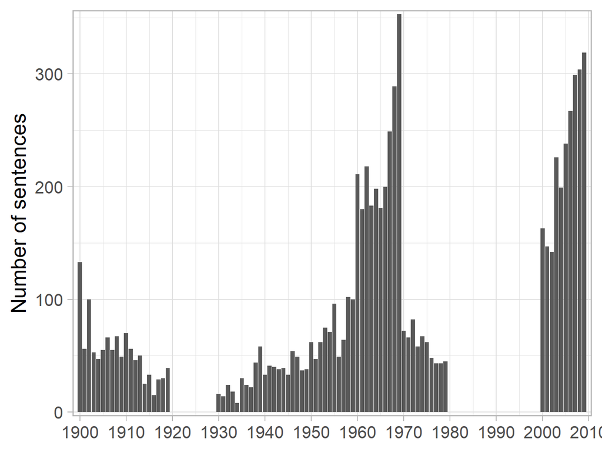

### Closest sentence from ‘rational’ and ‘rationality’ of the backbone community

| Sentence | Title | Year | Journal | Authors | Words Similarity |
| --- | --- | --- | --- | --- | --- |
| Basing ourselves on two alternative interpretations of the requirement of rationality in social choice, we identify in this paper the respective sets of necessary and sufficient conditions on the patt… | Necessary and sufficient conditions for rational choice under majority decision | 1969 | Journal of Economic Theory | Sen A. | 0.716 |
| To the extent that politicians are rational, voters cannot be so; to the extent that voters are rational they cannot have the equal effective demand that democratic theory asserts; if all men are rati… | [Market Concepts in Political Theory](https://http://www.jstor.org/stable/139435) | 1961 | The Canadian Journal of Economics and Political Science / Revue canadienne d’Economique et de Science politique | C. B. Macpherson | 0.708 |
| This aspect of bounded rationality is often neglected in a policy setting. | [An experimental study of compliance and leverage in auditing and regulatory enforcement](https://doi.org/10.1093/ei/cbj019) | 2006 | Economic Inquiry | Cason T.N. | 0.704 |
| Policy analysts therefore rely on technical rationality, with its foundations in instrumental rationality, as the essential arbiter of these claims for attention (Meppem and Bourke, 1999). | The discursive community: Evolving institutional structures for planning sustainability | 2000 | Ecological Economics | Meppem T. | 0.696 |
| Thus the elimination of C might have-and legitimately so from the point of view of individual rationality as well as social welfare-an effect upon the outcome.7 C. Another Collective Decision, with Vo… | [The Possibility of a Social Welfare Function](https://http://www.jstor.org/stable/1815299) | 1966 | The American Economic Review | James S. Coleman | 0.696 |
| Such a schematic approach is preferred over a messy and more naturalistic representation of the policy domain, because the assumption is that the ‘rationality’ of a process can be determined in relati… | [The production and use of knowledge in regulatory impact assessment - An empirical analysis](https://doi.org/10.1016/j.forpol.2009.01.004) | 2009 | Forest Policy and Economics | Hertin J. | 0.693 |
| This paper provides an answer to this question in the sense that it states conditions under which the optimal policy is to provide a signal that solves the bounded rationality problem. | Investors’s distrust and the marketing of new financial assets | 2004 | Quarterly Review of Economics and Finance | Kawamura E. | 0.692 |
| Buchanan and Tullock (1962, especially p. 32) argue that there is no reason to expect social choice to be rational or to suggest that it is desirable, and in an appendix to this book, Tullock states t… | [Graph-Theoretic Approaches to the Theory of Social Choice](https://http://www.jstor.org/stable/30022566) | 1968 | Public Choice | Michael Taylor | 0.692 |
| It is natural for the policy maker in exercising this control to aspire to rational decisions. | [Some Reflections on Rational Policy for Economic Development in Underdeveloped Areas](https://http://www.jstor.org/stable/1151649) | 1954 | Economic Development and Cultural Change | Ponna Wignaraja | 0.692 |
| There has to be a decision-making and an executing function on both levels and in a more rational association than at present. | [THE COMPREHENSIVE REFORM OF MANAGING THE NATIONAL ECONOMY IN HUNGARY](https://http://www.jstor.org/stable/40694541) | 1966 | Acta Oeconomica | R. Nyers | 0.690 |
| If the various constituent elements out of which such pseudo-principles are made up be separated from each other, if the general proposition be carefully distinguished from all kinds of working hypoth… | [What has Philosophy to Contribute to the Social Sciences, and to Economics in Particular?](https://http://www.jstor.org/stable/2549250) | 1936 | Economica | Harro Bernadelli | 0.685 |
| The use of an appropriate theory governing policy making procedures thus forms a crucial condition of rational policy. | [The Ambiguous Rationality of Economic Policy](https://http://www.jstor.org/stable/1991399) | 1972 | Journal of Money, Credit and Banking | Karl Brunner | 0.685 |
| In such instances again genuine decisions based on the emergence of new expectations are one but not the only possibility. | [Psychological Analysis of Business Decisions and Expectations](https://http://www.jstor.org/stable/1802255) | 1946 | The American Economic Review | George Katona | 0.680 |
| There are thus some contradictions, in the implementation of policies which are by themselves rational and defensible. | [Employment and Unemployment in the Indian Economy: Problems of Classification, Measurement, and Policy](https://http://www.jstor.org/stable/1151636) | 1959 | Economic Development and Cultural Change | K. N. Raj | 0.680 |
| We also verify the rationality of our initial assumptions that sequentially deciding policymakers can take as given the current policy choice of the other policymaker, as well as all future policies a… | [Monetary conservatism and fiscal policy](https://doi.org/10.1016/j.jmoneco.2008.09.003) | 2008 | Journal of Monetary Economics | Adam K. | 0.679 |
| We summarise them in relation to five ‘illusions of rational policy analysis’. | [The production and use of knowledge in regulatory impact assessment - An empirical analysis](https://doi.org/10.1016/j.forpol.2009.01.004) | 2009 | Forest Policy and Economics | Hertin J. | 0.678 |
| The rational model of policy-making assumes that decision-makers base their actions on knowledge (Simon, 1957; Dror, 1989). | Information-Communications Technologies (ICT) and transport: Does knowledge underpin policy? | 2002 | Telecommunications Policy | Cohen G. | 0.678 |
| The above discussion should be sufficient to show that when individuals are released from restrictive conditions upon behavior and information (i.e., voting on only one issue and complete absence of i… | [The Possibility of a Social Welfare Function](https://http://www.jstor.org/stable/1815299) | 1966 | The American Economic Review | James S. Coleman | 0.676 |
| Given the process of policy evaluation and decision-making as outlined above, it would be too restraining to award a policy the grade “rational” only if it reached the highest score possible under pre… | [Synoptic versus Incremental Scholarly Advice in Economic Policy: Some Implications of So-Called “Rational” Tax Systems](https://http://www.jstor.org/stable/40910769) | 1970 | FinanzArchiv / Public Finance Analysis | Gunther Engelhardt | 0.676 |
| If rational analysis is theoretically possible, the resulting policy proposals must be framed with a view to still other considerations. | [Economic Theory, Value Judgments, and Economic Policy](https://http://www.jstor.org/stable/3485033) | 1955 | The American Journal of Economics and Sociology | Forest G. Hill | 0.675 |

### Closest sentences of the backbone community’s centroid

| Sentence | Title | Year | Journal | Authors | Similarity to Backbone Centroid |
| --- | --- | --- | --- | --- | --- |
| We may reasonably conclude, therefore, that not only the cost of reproduction of the physical property for railway purposes, but also its strategic location and the ability with which it is managed as… | [Valuation of Railways, with Especial Reference to the Physical Valuation in Minnesota](https://http://www.jstor.org/stable/1822391) | 1909 | Journal of Political Economy | Samuel O. Dunn | 0.886 |
| Did space permit, it could easily be shown that the present law is sufificient to afford relief from all evils in, the field of railway rates, if one judges the question of the reasonableness and just… | [Railway Rates as Protective Tariffs](https://http://www.jstor.org/stable/1817278) | 1906 | Journal of Political Economy | Hugo R. Meyer | 0.865 |
| The model described in the previous section yields several interesting policy implications. | Privatization: A theoretical framework | 2001 | Journal of International Financial Markets Institutions and Money | Errunza V.R. | 0.862 |
| Here we find in popular discussion considerable complaint that the taxation which is supposed to be more or less in accordance with the principle of ability or cost of service rendered is not more exa… | [Equity and Economy in Taxation](https://http://www.jstor.org/stable/2957407) | 1901 | The Economic Journal | Edwin Cannan | 0.859 |
| He argues that where differences of wealth may fairly be presumed to be in a measure due to the state’s own acts of omission or commission, allowance should be made therefor in the tax system.35 He co… | [Progressive Taxation in Theory and Practice](https://www.jstor.org/stable/10.2307/3000009) | 1908 | American Economic Association Quarterly | E. R. A. Seligman | 0.846 |
| Nonetheless, there are considerations which, in certain instances, enable one to make a logical selection. | [Substitution, Technical Progress, and Returns to Scale](https://http://www.jstor.org/stable/1816270) | 1965 | The American Economic Review | C. E. Ferguson | 0.845 |
| “36 It is a poor argument which defends degressive taxation, even though illogical, because it is just; and which opposes prog-ressive taxation on the ground that it is unjust, althougLh the same reas… | [Progressive Taxation in Theory and Practice](https://www.jstor.org/stable/10.2307/3000009) | 1908 | American Economic Association Quarterly | E. R. A. Seligman | 0.845 |
| In this section we thus consider how the optimal policy compares with types of policies that are more likely to be pursued. | Stabilization policy in an open economy | 2002 | Journal of Macroeconomics | Andersen T.M. | 0.843 |
| The model presented here yields several new policy conclusions. | Why present-oriented societies undergo cycles of drug epidemics | 2002 | Journal of Economic Dynamics and Control | Behrens D.A. | 0.841 |
| The propositions respecting incipient taxes can best be dis cussed by mathematical methods, but first of all an attempt will be made to show, by general reasoning, that they are not opposed to common … | [The Theory of Incipient Taxes](https://http://www.jstor.org/stable/2221475) | 1906 | The Economic Journal | C. F. Bickerdike | 0.840 |
| Decisions are often based on something else. | [Farm Fundamentalism: Its Future](https://http://www.jstor.org/stable/1236057) | 1962 | Journal of Farm Economics | Don F. Hadwiger | 0.839 |
| Turning now from conIsideration of the justice of this form of taxation to a consideration of its wisdom from the view point of public policy, we find still further grounds for criticism. | [Public Policy Concerning Franchise Values: A Problem in Taxation](https://http://www.jstor.org/stable/1819351) | 1901 | Journal of Political Economy | George C. Sikes | 0.838 |
| he principle of the single tax not to be questioned, 279.- The method of taxation an unfortunate device, 281. | [The Single Tax in the English Budget](https://http://www.jstor.org/stable/1883559) | 1910 | The Quarterly Journal of Economics | H. J. Davenport | 0.837 |
| Some of my readers may be prevented from according full assent to the notions brought forward in this article by their acceptance of a principle of taxation that is steadily winning the confidence of … | [The Utility of Income and Progressive Taxation](https://http://www.jstor.org/stable/2222207) | 1913 | The Economic Journal | S. J. Chapman | 0.837 |
| On the basis of these empirical results, which prove consistent with our hypotheses (Section 5), we draw some policy implications in the conclusions (Section 6). | Bank-firm relationships and allocative efficiency in Northeastern and Central Italy and in the South | 2000 | Journal of Banking and Finance | Ferri G. | 0.834 |

### Closest sentences of each HDBSCAN cluster’s centroid composing the backbone community

| Sentence | Title | Year | Journal | Authors | Similarity to HDSBSCAN Centroid |
| --- | --- | --- | --- | --- | --- |
| Here we find in popular discussion considerable complaint that the taxation which is supposed to be more or less in accordance with the principle of ability or cost of service rendered is not more exa… | [Equity and Economy in Taxation](https://http://www.jstor.org/stable/2957407) | 1901 | The Economic Journal | Edwin Cannan | 0.859 |
| He argues that where differences of wealth may fairly be presumed to be in a measure due to the state’s own acts of omission or commission, allowance should be made therefor in the tax system.35 He co… | [Progressive Taxation in Theory and Practice](https://www.jstor.org/stable/10.2307/3000009) | 1908 | American Economic Association Quarterly | E. R. A. Seligman | 0.846 |
| “36 It is a poor argument which defends degressive taxation, even though illogical, because it is just; and which opposes prog-ressive taxation on the ground that it is unjust, althougLh the same reas… | [Progressive Taxation in Theory and Practice](https://www.jstor.org/stable/10.2307/3000009) | 1908 | American Economic Association Quarterly | E. R. A. Seligman | 0.845 |
| The propositions respecting incipient taxes can best be dis cussed by mathematical methods, but first of all an attempt will be made to show, by general reasoning, that they are not opposed to common … | [The Theory of Incipient Taxes](https://http://www.jstor.org/stable/2221475) | 1906 | The Economic Journal | C. F. Bickerdike | 0.840 |
| Turning now from conIsideration of the justice of this form of taxation to a consideration of its wisdom from the view point of public policy, we find still further grounds for criticism. | [Public Policy Concerning Franchise Values: A Problem in Taxation](https://http://www.jstor.org/stable/1819351) | 1901 | Journal of Political Economy | George C. Sikes | 0.838 |
| he principle of the single tax not to be questioned, 279.- The method of taxation an unfortunate device, 281. | [The Single Tax in the English Budget](https://http://www.jstor.org/stable/1883559) | 1910 | The Quarterly Journal of Economics | H. J. Davenport | 0.837 |
| Some of my readers may be prevented from according full assent to the notions brought forward in this article by their acceptance of a principle of taxation that is steadily winning the confidence of … | [The Utility of Income and Progressive Taxation](https://http://www.jstor.org/stable/2222207) | 1913 | The Economic Journal | S. J. Chapman | 0.837 |
| While the theoretical objections to progressive taxation are thus in large measure destitute of fotundation, it is possible to draw only this rather vague conclusion as to the geeneral legitimacy of t… | [Progressive Taxation in Theory and Practice](https://www.jstor.org/stable/10.2307/3000009) | 1908 | American Economic Association Quarterly | E. R. A. Seligman | 0.833 |
| If one once grants that a tax which is to produce an equal sacrifice must not take away any of those miieans which are needed to cover essential wants, then for the sake of consistency the deductions … | [The Theory of Progressive Taxation](https://http://www.jstor.org/stable/2957408) | 1901 | The Economic Journal | G. Cassel | 0.830 |
| In so far, however, as taxes are nlecessary, justice should be observed; and justice conlsists in apportioning taxation according to family’ But faculty seems to Bodin simply to denote means or proper… | [Progressive Taxation in Theory and Practice](https://www.jstor.org/stable/10.2307/3000009) | 1908 | American Economic Association Quarterly | E. R. A. Seligman | 0.828 |

| Sentence | Title | Year | Journal | Authors | Similarity to HDSBSCAN Centroid |
| --- | --- | --- | --- | --- | --- |
| Foreible as is this eornplaeent reeital of the wrongs whieh parliametlt had intended to infliet llpOll the eolonies, it is but partial and ineomplete, but it was one of the signs whieh ellabled the eo… | [Currency and Banking in the Province of the Massachusetts-Bay: Part I. Currency](https://www.jstor.org/stable/10.2307/2485780) | 1900 | Publications of the American Economic Association | Andrew McFarland Davis | 0.799 |
| In a government like ours theories of public good or necessity are often so plausible or sound as to command popular approval; but courts are not permitted to forget that the law is the only chart by … | [The New York Workmen’s Compensation Act Decision](https://http://www.jstor.org/stable/1819427) | 1911 | Journal of Political Economy | James Parker Hall | 0.787 |
| This, together with the fact that no question under the law was ever carried into the courts, points to the conclusion that the object for which it was levied appealed to the loyalty of the citizens a… | [The Income Tax in Georgia](https://http://www.jstor.org/stable/1821038) | 1910 | Journal of Political Economy | William A. Shelton | 0.786 |
| By I882 a measure which its friends hoped and its opponents feared would be much more effective than its predecessors, not only passed the House with scarcely any opposition, but commanded the time of… | [The Child Labor Policy of New Jersey](https://www.jstor.org/stable/10.2307/3000007) | 1910 | American Economic Association Quarterly | Arthur Sargent Field | 0.784 |
| It is surely not often that a law can thus receive the unqualified approval of those who are diametrically opposed in their theories; and I am inclined to think that it is an evidence of the real stat… | [The Public Service Commissions Law of New York State](https://www.jstor.org/stable/10.2307/3000000) | 1908 | American Economic Association Quarterly | Thomas M. Osborne | 0.783 |
| In tlle effort to take into its own hands not only tlle origina- tiOll of all appropriatiolls, but also tlle control of all disbursements, which soon becallle tlle settled policy of the representative… | [Currency and Banking in the Province of the Massachusetts-Bay: Part I. Currency](https://www.jstor.org/stable/10.2307/2485780) | 1900 | Publications of the American Economic Association | Andrew McFarland Davis | 0.782 |
| Even while indicting law in general for its conservatism, we inveigh against statutes because of their unstable character.1 The common law must therefore be singled out as the particular culprit that … | [The Economic Function of the Common Law](https://http://www.jstor.org/stable/1820903) | 1918 | Journal of Political Economy | Homer Hoyt | 0.781 |
| Inspired by this doctrine, and heedless of the warnings given by the high legal authorities already quoted, many of our state legislatures have enacted laws that prohibit agreements and com? | [The Conservation of Business Opportunity](https://http://www.jstor.org/stable/1820627) | 1912 | Journal of Political Economy | Gilbert H. Montague | 0.780 |
| Law and custom can at best never keep pace with the needs which they are made to meet, for the simple reason that the need must be there before it can be felt, and it must be felt in a substantial way… | [The Changing Basis of Economic Responsibility](https://http://www.jstor.org/stable/1819437) | 1916 | Journal of Political Economy | J. Maurice Clark | 0.776 |
| Their relatiolls witll tlle governor were eloser than their eonneetion witll the llouse, and they were to be relied vlpon to suplDort llim Illlless sollle recognized question of principle was illvolve… | [Currency and Banking in the Province of the Massachusetts-Bay: Part I. Currency](https://www.jstor.org/stable/10.2307/2485780) | 1900 | Publications of the American Economic Association | Andrew McFarland Davis | 0.774 |

| Sentence | Title | Year | Journal | Authors | Similarity to HDSBSCAN Centroid |
| --- | --- | --- | --- | --- | --- |
| We may reasonably conclude, therefore, that not only the cost of reproduction of the physical property for railway purposes, but also its strategic location and the ability with which it is managed as… | [Valuation of Railways, with Especial Reference to the Physical Valuation in Minnesota](https://http://www.jstor.org/stable/1822391) | 1909 | Journal of Political Economy | Samuel O. Dunn | 0.886 |
| Did space permit, it could easily be shown that the present law is sufificient to afford relief from all evils in, the field of railway rates, if one judges the question of the reasonableness and just… | [Railway Rates as Protective Tariffs](https://http://www.jstor.org/stable/1817278) | 1906 | Journal of Political Economy | Hugo R. Meyer | 0.865 |
| Conclusion.-There is scarcely a shadow of doubt that the necessary protection would have been secured by the railways before this, had not the companies’ surveyors shown such bitter hostility to the ”… | [A Plea for Reform in the Assessment of Railways](https://http://www.jstor.org/stable/2220704) | 1908 | The Economic Journal | F. O. Lyons | 0.827 |
| It is perfectly true that the service which the railroads are now giving is not the service they gave under other conditions and other rates, but when we are insisting upon improved service and increa… | [Waterways: Their Place in our Transportation System](https://http://www.jstor.org/stable/1819644) | 1915 | Journal of Political Economy | Walter L. Fisher | 0.824 |
| In discussing the problems of the regulation of railway rates in the form in which these are now before the American people, it has frequently been assumed, for partisan purposes, and depending upon t… | [Government Regulation of Railway Rates](https://www.jstor.org/stable/10.2307/2999966) | 1906 | Publications of the American Economic Association | Balthasar Henry Meyer | 0.824 |
| Since the purpose of the present inquiry is to show how a consideration of the economic and social conditions affecting rate making has led the Interstate Commerce Commission to develop certain fundam… | [Railway Rate Theories of the Interstate Commerce Commission. II](https://http://www.jstor.org/stable/1884951) | 1911 | The Quarterly Journal of Economics | M. B. Hammond | 0.814 |
| If I have succeeded in pointing out “certain considerations in railway rate making,” they are the value of the property implying a fair return thereon, the cost of the service, and a sound public poli… | [Certain Considerations in Railway Rate Making](https://http://www.jstor.org/stable/1827704) | 1914 | The American Economic Review | Balthasar H. Meyer | 0.811 |
| Recently, however, as above indicated, the value of railroad property has been attacked in the field of public discussion and in the courts, and men of prominence propose definitions of value which le… | [“Valuation of Railway Property for Purposes of Rate Regulation”](https://http://www.jstor.org/stable/1819530) | 1915 | Journal of Political Economy | Pierce Butler | 0.810 |
| not infrequently refused to fit the theories’, and the public servants have allowed, or been constrained to allow, the railways to b ’run, not in the permanent interest of the community as a whole, bu… | [The Relation of Railways to the State](https://http://www.jstor.org/stable/2220619) | 1908 | The Economic Journal | W. M. Acworth | 0.809 |
| Another clause of the Constitution which has been brought into the discussion for the purpose not of demonstrating the impossibility, but rather the undesirability, of taking the rate-making power out… | [The Interstate Commerce Act as Amended](https://http://www.jstor.org/stable/1883749) | 1906 | The Quarterly Journal of Economics | Frank Haigh Dixon | 0.808 |

| Sentence | Title | Year | Journal | Authors | Similarity to HDSBSCAN Centroid |
| --- | --- | --- | --- | --- | --- |
| The dual aim of rendering the tariff more simple and effective for its purpose of raising revenue, arnd of purging it of Protectionist suspicion, may indeed have been present to their minds; but they … | [Economic Theory and Fiscal Policy](https://http://www.jstor.org/stable/2221360) | 1904 | The Economic Journal | L. L. Price | 0.828 |
| That preferential tariffs are the particular machinery, which the colonies, throug,h the mouths of their Premiers, have expressed a wish to use to further this result, has been placed on authoritative… | [The Economic Possibilities of an Imperial Fiscal Policy](https://http://www.jstor.org/stable/2221316) | 1903 | The Economic Journal | L. L. Price | 0.806 |
| Every Protective tariff in the world bears upon its face the impress of the theory of foreign trade which possessed the men who established it. | [Protection of Infant Industries](https://http://www.jstor.org/stable/2221136) | 1906 | The Economic Journal | H. O. Meredith | 0.802 |
| The moral evils involved in the undue pressure of private interests on our law making body constitute to me far and away the most important indictment against the tariff, but there is no occasion for … | [The Best Way to Work for Tariff Revision](https://www.jstor.org/stable/10.2307/2635434) | 1909 | American Economic Association Quarterly | H. C. Emery | 0.799 |
| It need hardly be recalled to your thoughts that the revenue-tariff advocates would find the advantage afforded by lowering the tariff, or ally particular item of it, not in the privilege conferred on… | [Do Reciprocally Preferential Tariffs Tend Towards Free Trade?](https://www.jstor.org/stable/10.2307/2999845) | 1905 | Publications of the American Economic Association | A. W. Flux | 0.795 |
| If these mills needed the extra protection, it should have been openly asked for; not sought through the medium of small clauses in the tariff law which were not explained to Congress and the importan… | [Making a Tariff Law](https://http://www.jstor.org/stable/1820064) | 1910 | Journal of Political Economy | Samuel M. Evans | 0.791 |
| One who argues after this fashion would seem not to be able to use the principle of a ” competitive tariff,” which assumes a partition of the market between the domestic producer and the foreign; or a… | [The Tariff Act of 1913](https://http://www.jstor.org/stable/1884927) | 1913 | The Quarterly Journal of Economics | F. W. Taussig | 0.791 |
| It was reasoned with force that, if the administration really felt the cogency of the German tariff argument, it coluld well shoiwr this feeling in a, practical way by altering the objectionable featu… | [Reciprocity with Germany](https://http://www.jstor.org/stable/1819492) | 1907 | Journal of Political Economy | H. Parker Willis | 0.788 |
| Why a tariff based upon foreign costs should be regarded as essentially fair and just to all concerned is difficult to comprehend, unless a condition of commercial isolation and of complete embargo up… | [Cost of Production as a Basis of Tariff Revision](https://http://www.jstor.org/stable/1820498) | 1909 | Journal of Political Economy | John Cummings | 0.788 |
| It must therefore not surprise us to find that only the other day the gifted Prime Minister of England issued a noteworthy pro- nunciamento on the tariff agitation, in which he employed as one of the … | [Social Aspects of Economic Law](https://www.jstor.org/stable/10.2307/2999857) | 1904 | Publications of the American Economic Association | Edwin R. A. Seligman | 0.787 |

| Sentence | Title | Year | Journal | Authors | Similarity to HDSBSCAN Centroid |
| --- | --- | --- | --- | --- | --- |
| If it is to be retained under the present distribution of political power, some means must be found whereby the tendency to throw upon the state the responsibility for decision in minor cases may be c… | [The German System of Arbitration](https://http://www.jstor.org/stable/1821745) | 1931 | Journal of Political Economy | William T. Ham | 0.768 |
| To stress the rigidity of customary processes, and hence the difficulty of making changes, is proper enough; but to assume that the rigidity is so great that orderly changes can be managed only by leg… | [Commons on Institutional Economics](https://http://www.jstor.org/stable/1803817) | 1937 | The American Economic Review | Clifford L. James | 0.765 |
| If we say that a State in the long run cannot be maintained without the consent of the governed we are stating a psychological and empirical, and not a juristic theory; if we say that a State ought to… | [The Concept of the State](https://http://www.jstor.org/stable/2548973) | 1932 | Economica | Hermann Kantorowicz | 0.760 |
| The next point has to do with the nature of political coercion, beyond its negative role, and with the nature of the state. | [Ethics and Economic Reform. I. The Ethics of Liberalism](https://http://www.jstor.org/stable/2549075) | 1939 | Economica | F. H. Knight | 0.751 |
| Then follow some justifiable strictures on the undue preference shown in the past by the courts “to contemplate the probable intent of the parties rather than to analyse the consequences of behavior,”… | [Planning For Totalitarian Monopoly](https://http://www.jstor.org/stable/1824057) | 1937 | Journal of Political Economy | Frank Albert Fetter | 0.747 |
| It may be inadequate in securing the “admittedly” desirable unity of action, or, at the opposite extreme, may overconcentrate power, “unduly” sacrificing individual liberty to coherence. | [Comment on Mr. Slichter’s Comment and on the Issues](https://http://www.jstor.org/stable/1822904) | 1932 | Journal of Political Economy | Frank H. Knight | 0.742 |
| They emphasize the freedom of discussion in arriving at decisions, but they confess (p. 42) that “counter-revolutionary” suggestions would not be tolerated, without attempting to show how much is embr… | [Soviet Communism: A New Civilization?](https://http://www.jstor.org/stable/1882504) | 1936 | The Quarterly Journal of Economics | Redvers Opie | 0.740 |
| Practical considerations may have dictated the necessity for compromise with ideals in granting past approvals, but it is unrealistic to hold that, had control been by initiation rather than by veto, … | [Railroad Fixed Charges in Bankruptcy Proceedings](https://http://www.jstor.org/stable/1829692) | 1939 | Journal of Political Economy | William H. Moore | 0.737 |
| The real clash of opinion was more subtle and less advertised by public discussion: granting that some reform is desirable and perhaps essential, shall we have enough of it to result in a postponed or… | [Official Policies and Economic Prospects](https://http://www.jstor.org/stable/1926703) | 1934 | The Review of Economics and Statistics | W. L. Crum | 0.735 |
| In deciding whether an Act of a provincial legislature should be allowed or sanctioned, the government must not only consider whether it affects the interest of the whole Dominion or not; but also whe… | [Disallowance of Provincial Acts, Reservation of Provincial Bills, and Refusal of Assent by Lieutenant-Governors since 1867](https://http://www.jstor.org/stable/136754) | 1938 | The Canadian Journal of Economics and Political Science / Revue canadienne d’Economique et de Science politique | Eugene Forsey | 0.732 |

| Sentence | Title | Year | Journal | Authors | Similarity to HDSBSCAN Centroid |
| --- | --- | --- | --- | --- | --- |
| A consideration of taxation and a minimum of subsistence leads one to the conclusion that ability to pay should be given more weight in formulating our tax policies, indefinite as this standard is. | [Taxation and the Minimum of Subsistence](https://http://www.jstor.org/stable/253) | 1933 | The American Economic Review | Alfred G. Buehler | 0.795 |
| Until there is established a reasonable basis for a belief not only in the reality of the hypothesis that the curve of diminishing marginal utility of money income is steeper than a rectangular hyperb… | [Recent and Contemporary Theories of Progressive Taxation](https://http://www.jstor.org/stable/1824777) | 1938 | Journal of Political Economy | Elmer D. Fagan | 0.786 |
| In a certain ultimate and fundamental sense, taxation reform is of equal importance, to be sure; but expenditure control derives its greater significance from the psychological, political and fallacio… | [Tax Relief through Rational Expenditure Control](https://http://www.jstor.org/stable/1231484) | 1935 | Journal of Farm Economics | Harley L. Lutz | 0.780 |
| derive from the tax, and that any appraisal of the desirability of a given tax ought to consider them. | [The Incidence and Effects of Taxation: Some Theoretical Aspects](https://http://www.jstor.org/stable/1801984) | 1937 | The American Economic Review | M. Slade Kendrick | 0.780 |
| Although he would evidently confine the discussion of the effects of public expenditures to those taxes where the receipts clearly change the supply of or the demand for the taxed object, it appears m… | [Public Expenditures and the Incidence of Taxes: Some Theoretical Considerations](https://http://www.jstor.org/stable/1806303) | 1938 | The American Economic Review | Alfred G. Buehler | 0.778 |
| The points made respecting application of the principle of declining marginal utility to money, and the existence of sacrifice in progressive taxation hold for this view also. | [The Ability-to-Pay Theory of Taxation](https://http://www.jstor.org/stable/1806989) | 1939 | The American Economic Review | M. Slade Kendrick | 0.777 |
| To do this satisfactorily and with acceptance would certainly not be easy, but it is precisely my case here, as elsewhere, that the difficulties of rational taxation ought to be faced: that we can no … | [Rates and Taxes](https://http://www.jstor.org/stable/2224799) | 1939 | The Economic Journal | H. O. Meredith | 0.777 |
| For the early steps in a purely theoretical discussion of sacrifice in taxation, this hypothesis is highly valuable if not indispensable. | [Recent and Contemporary Theories of Progressive Taxation](https://http://www.jstor.org/stable/1824777) | 1938 | Journal of Political Economy | Elmer D. Fagan | 0.771 |
| This doctrine has been accepted by numerous economists in various forms and on various grounds; other economists have ignored it or openly rejected it; while the framers of our tax laws have considere… | [Taxation and the Minimum of Subsistence](https://http://www.jstor.org/stable/253) | 1933 | The American Economic Review | Alfred G. Buehler | 0.771 |
| It was not necessary, however, for the justification of progressive taxation to assume any rigidly measurable utility, and it is doubtful whether the introduction of the concept of utility into this p… | [Equilibrium and Wealth: A Word of Encouragement to Economists](https://http://www.jstor.org/stable/137181) | 1939 | The Canadian Journal of Economics and Political Science / Revue canadienne d’Economique et de Science politique | K. E. Boulding | 0.769 |

| Sentence | Title | Year | Journal | Authors | Similarity to HDSBSCAN Centroid |
| --- | --- | --- | --- | --- | --- |
| Questions of public policy are not always answered, and, perhaps, less often decided, on the basis of reason and objective logic. | [A Report on an Experiment by an Ad Hoc Consensus Committee](https://http://www.jstor.org/stable/1818468) | 1945 | The American Economic Review | James Washington Bell | 0.799 |
| Though there may be valid political considerations. | [The Nature and Scope of Collective Bargaining](https://http://www.jstor.org/stable/1882846) | 1944 | The Quarterly Journal of Economics | Neil Chamberlain | 0.781 |
| How much difference of opinion is compatible with the maintenance of common policy depends on many varying factors. | [The Concerted Regulation of Price and Output](https://http://www.jstor.org/stable/2225936) | 1948 | The Economic Journal | E. G. Dowdell | 0.781 |
| Since the policy which is suitable for one situation may be the wrong medicine for another, it is only in this way that policy may be judged. | [The Declining American Maritime Industries: An Unsolved Problem, 1860-1940](https://http://www.jstor.org/stable/2113077) | 1946 | The Journal of Economic History | John G. B. Hutchins | 0.779 |
| V Sometimes right policies are followed for the wrong reasons. | [The Effect of Interest Rate Increases on the Banking System](https://http://www.jstor.org/stable/1810106) | 1945 | The American Economic Review | Paul A. Samuelson | 0.777 |
| Here again, however, political motives may dictate less rational and more restrictive policies. | [The European Recovery Program and the American Farmer](https://http://www.jstor.org/stable/1232856) | 1949 | Journal of Farm Economics | Helen C. Farnsworth | 0.772 |
| Such considerations are matter of national policy “. | [The Scott Committee Report](https://http://www.jstor.org/stable/2549650) | 1943 | Economica | D. H. Macgregor | 0.768 |
| Policy may be based on one of two possible hypotheses. | [A Model of the Forty-Month or Trade Cycle](https://http://www.jstor.org/stable/1825433) | 1942 | Journal of Political Economy | Joshua C. Hubbard | 0.762 |
| The wisdom of this policy depends on numerous factors. | [The Official and Unofficial Markets for Sterling](https://http://www.jstor.org/stable/1884725) | 1940 | The Quarterly Journal of Economics | S. E. Harris | 0.762 |
| Political influences have their proper place in the development of guiding policies through legislative action; but in the execution of these policies as established by law, the responsible administra… | [Law and Economics](https://http://www.jstor.org/stable/1802253) | 1946 | The American Economic Review | I. L. Sharfman | 0.758 |

| Sentence | Title | Year | Journal | Authors | Similarity to HDSBSCAN Centroid |
| --- | --- | --- | --- | --- | --- |
| But the cruciality of certain decisions is not something to be determined on abstract grounds by means of an analysis presuming the universal pre-eminence of limited hypotheses; it is a matter that de… | [The Entrepreneur: The Firm](https://http://www.jstor.org/stable/1829414) | 1944 | Journal of Political Economy | James H. Stauss | 0.823 |
| Decisions are made under these conditions. | [The Entrepreneur: The Firm](https://http://www.jstor.org/stable/1829414) | 1944 | Journal of Political Economy | James H. Stauss | 0.797 |
| In such instances again genuine decisions based on the emergence of new expectations are one but not the only possibility. | [Psychological Analysis of Business Decisions and Expectations](https://http://www.jstor.org/stable/1802255) | 1946 | The American Economic Review | George Katona | 0.793 |
| The making of these decisions depends on a host of other considera- | [Long-Time Adjustments in Forage Land Utilization in the Northeast Region](https://http://www.jstor.org/stable/1232557) | 1946 | Journal of Farm Economics | Virgil L. Hurlburt | 0.785 |
| When a man takes a decision on any matter whatever, he tacitly or unconsciously takes into account a great range of circumstances which are all relevant, in the sense that if any one of them were mate… | [Interest-Rates and the Pace of Investment](https://http://www.jstor.org/stable/2225616) | 1946 | The Economic Journal | G. L. S. Shackle | 0.785 |
| In such cases, it is necessary to ascertain the real objective of the decisions (e.g. | [The Scope and Method of Economics](https://http://www.jstor.org/stable/2296113) | 1945 | The Review of Economic Studies | O. Lange | 0.783 |
| In the vast majority of decisions which are made there are very definite factors which determine the limits within which decisions may fall. | [Economic Planning and the Problem of Full Employment](https://http://www.jstor.org/stable/1814503) | 1940 | The American Economic Review | Calvin B. Hoover | 0.773 |
| Again, not only are decisions arrived at, and indeed conditioned by an environment of social, political, and economic factors (including contemporary thought), but one decision in some measure conditi… | [An Approach to the Study of Entrepreneurship: A Tribute to Edwin F. Gay](https://http://www.jstor.org/stable/2113071) | 1946 | The Journal of Economic History | Arthur H. Cole | 0.772 |
| When these factors are appreciated, one sees clearly that many decisions cannot be called “right” or “wrong.” | [The Financial Policy of Corporations](https://http://www.jstor.org/stable/1882755) | 1943 | The Quarterly Journal of Economics | Pearson Hunt | 0.770 |
| It is conceivable that the choice cannot be left to objective criteria. | [Burns and Mitchell on Business Cycles](https://http://www.jstor.org/stable/1826221) | 1947 | Journal of Political Economy | E. S. Shaw | 0.762 |

| Sentence | Title | Year | Journal | Authors | Similarity to HDSBSCAN Centroid |
| --- | --- | --- | --- | --- | --- |
| Moreover, the very quality which appears as a merit from the economic point of view, namely, that it can be adapted to restrict specific types of spending, is a liability from the political point of v… | [A Suggestion for the Control of Peacetime Inflation](https://http://www.jstor.org/stable/2975425) | 1949 | The Journal of Finance | David Gordon Tyndall | 0.781 |
| The writer raises this question, not because he has any alternative method for taxation, but because he wishes to suggest that the question might well be held open. | [Long-Run Considerations in Employment Stabilization and Unemployment Compensation](https://http://www.jstor.org/stable/1883034) | 1941 | The Quarterly Journal of Economics | Charles E. Lindblom | 0.777 |
| Whether a particular form of taxation, or the decision to do by government decree what is normally done by taxation, is desirable or not, turns more and more on the state of political sentiment, and l… | [Some Problems of War Finance in Canada](https://http://www.jstor.org/stable/136908) | 1940 | The Canadian Journal of Economics and Political Science / Revue canadienne d’Economique et de Science politique | J. F. Parkinson | 0.774 |
| “8 The administrative difficulties inherent in a compensatory budget system would likely be multiplied manyfold as a result of public resistance to taxes were it understood that the government does no… | [A Critique of Functional Finance Through Quasi-Free Bank Credit](https://http://www.jstor.org/stable/1801839) | 1946 | The American Economic Review | J. Carl Poindexter | 0.774 |
| It is, of course, no discovery to learn that political considerations can prevent the achievement of desirable simplification of the tax system; but it is interesting to notice that at a time when a l… | [The Problem of Simplicity in the Enactment of Tax Legislation, 1920-40](https://http://www.jstor.org/stable/1825333) | 1941 | Journal of Political Economy | Kenyon E. Poole | 0.764 |
| Nevertheless, we ought to be aware of the fact that the decision is being made very largely on noneconomic grounds, that a really careful appraisal of the economic merits of this or any other program … | [The Incidence of the General Income Tax](https://http://www.jstor.org/stable/1815099) | 1942 | The American Economic Review | Eugene E. Oakes | 0.761 |
| There are probably those who will hesitate to accept the author’s basic premise that taxation should perform a dual function. | [Temporary National Economic Committee: Reviews of Monographs](https://http://www.jstor.org/stable/1805819) | 1941 | The American Economic Review | NA | 0.759 |
| The appropriateness of reliance on taxes of this type has always given | [Social Insurance in Evolution](https://http://www.jstor.org/stable/1818694) | 1944 | The American Economic Review | Eveline M. Burns | 0.756 |
| The formulation of economically sound tax systems becomes a purely intellectual exercise if, in the end, the members of Congress fail to grasp the many technical problems involved; or if, whether they… | [Congressional Tax Policies in 1943](https://http://www.jstor.org/stable/1807393) | 1944 | The American Economic Review | Mabel Newcomer | 0.748 |
| I do not here comment on the first of these views as to tax policy in strictly political terms-in terms of the probable appeal of such a policy to the more numerous groups of voters-or in terms of the… | [Postwar Federal Expenditures and Their Implications for Tax Policy](https://http://www.jstor.org/stable/1818458) | 1945 | The American Economic Review | W. L. Crum | 0.747 |

| Sentence | Title | Year | Journal | Authors | Similarity to HDSBSCAN Centroid |
| --- | --- | --- | --- | --- | --- |
| Some decisions, as between given pairs of alternatives, may be assumed to be imposed. | [A Difficulty in the Concept of Social Welfare](https://http://www.jstor.org/stable/1828886) | 1950 | Journal of Political Economy | Kenneth J. Arrow | 0.826 |
| or the criteria by which the choice is to be made. | [Regional Economic Reaction Paths](https://http://www.jstor.org/stable/1823547) | 1955 | The American Economic Review | F. T. Moore | 0.815 |
| It goes beyond the problem of making meaningful and correct statements and tries to furnish criteria for choosing a course of action. | [Are Business History and Economic Theory Compatible?](https://www.jstor.org/stable/10.2307/3111860) | 1955 | The Business History Review | Donald E. Stout | 0.804 |
| We shall think in terms of an individual confronted with conflicting criteria applied to a set of alternatives. | [Intransitivity, Utility, and the Aggregation of Preference Patterns](https://http://www.jstor.org/stable/1909827) | 1954 | Econometrica | Kenneth O. May | 0.802 |
| Further, it is clear that not all possible outcomes do, or should, exert equal influence on the decision-maker. | [Utility Theory, Decision Theory, and Profit Maximization](https://http://www.jstor.org/stable/1812912) | 1959 | The American Economic Review | Joseph E. Haring, Gorman C. Smith | 0.801 |
| Decisions are not made in a vacuum. | [The Insurance Curriculum: Retrospect and Prospect](https://www.jstor.org/stable/10.2307/250196) | 1959 | The Journal of Insurance | O. D. Dickerson | 0.798 |
| Otherwise the effects of decisions may be contrary to those intended. | [An Empirical Test of Sales-Tax Regressivity](https://http://www.jstor.org/stable/1826700) | 1959 | Journal of Political Economy | David G. Davies | 0.796 |
| The very basis or criterion for making a decision is harder to determine. | [Economics and Military Operations Research](https://http://www.jstor.org/stable/1927408) | 1958 | The Review of Economics and Statistics | Charles Hitch | 0.791 |
| Decisions are taken by a multitude of individuals. | [Expectations and Equilibrium](https://http://www.jstor.org/stable/2226527) | 1952 | The Economic Journal | F. H. Hahn | 0.791 |
| This is despite any change in the individual’s orderings on other alternatives.2 One’s view of this requirement will turn partly on whether he desires to allow different individuals an unequal influen… | [On the Concept of Social Welfare](https://http://www.jstor.org/stable/1884448) | 1954 | The Quarterly Journal of Economics | Abram Bergson | 0.790 |

| Sentence | Title | Year | Journal | Authors | Similarity to HDSBSCAN Centroid |
| --- | --- | --- | --- | --- | --- |
| In an actual policy decision, political considerations cannot be ignored. | [The Market Structure of Commercial Banking in the United States](https://http://www.jstor.org/stable/1879500) | 1951 | The Quarterly Journal of Economics | David A. Alhadeff | 0.796 |
| The reasons for political and social considerations are also evident from the results wvhich would be attained in each instance. | [Some Observations on Experience Rating in Unemployment Insurance](https://www.jstor.org/stable/10.2307/250335) | 1959 | The Journal of Insurance | John F. Adams | 0.784 |
| Moreover, in many, if not most, cases the efficacy of any particular economic measure in achieving the indicated end or goal will depend to a very considerable extent on political factors. | [Public Policy and Political Considerations](https://http://www.jstor.org/stable/1927016) | 1957 | The Review of Economics and Statistics | Betty G. Fishman, Leo Fishman | 0.779 |
| In other words, political efforts need not be used exclusively, as is so frequently the case, for the purpose of securing far-reaching modifica- | [Minimum Wages and Other Labor Standards Considered in Relation to Economic Growth in Underdeveloped Countries](https://http://www.jstor.org/stable/1234396) | 1956 | Journal of Farm Economics | John P. Windmuller | 0.768 |
| These are, in fact, basic decisions in social policy; and more often than not they require a political rather than a technical decision, although the former may be based upon the latter. | [Some Observations on Experience Rating in Unemployment Insurance](https://www.jstor.org/stable/10.2307/250335) | 1959 | The Journal of Insurance | John F. Adams | 0.768 |
| Decisions are essentially political ? | [Alternate Solutions: Voluntary and Compulsory Medical Care Insurance](https://www.jstor.org/stable/10.2307/250040) | 1951 | Journal of the American Association of University Teachers of Insurance | C. A. Kulp | 0.766 |
| Conclusion Where political and economic considerations are as closely interwoven as they have been during the course of the debates on this measure it is impossible to arrive at a completely objective… | [The Iron and Steel Act, 1949](https://http://www.jstor.org/stable/2227057) | 1950 | The Economic Journal | S. J. Langley | 0.760 |
| There are, however, political reasons why the authorities may make such a decision. | [Soviet Bloc Currency Conversions](https://http://www.jstor.org/stable/1810805) | 1954 | The American Economic Review | Edward Ames | 0.750 |
| Besides the realities of political pressures, another factor which limits the immediate relevance of theoretical considerations must be mentioned. | [Cost Allocation in Relation to Western Water Policies](https://http://www.jstor.org/stable/1233139) | 1954 | Journal of Farm Economics | S. V. Ciriacy-Wantrup | 0.746 |
| These political and social considerations are not mere alternatives to or compromises with the more strictly economic aspects of policy and program, but should be discriminately integrated with them. | [Ideal and Working Concepts of Full Employment](https://http://www.jstor.org/stable/1831581) | 1957 | The American Economic Review | Edwin G. Nourse | 0.742 |

| Sentence | Title | Year | Journal | Authors | Similarity to HDSBSCAN Centroid |
| --- | --- | --- | --- | --- | --- |
| Policy is often a resultant of decisions rather than a decision. | [Tinbergen on Policy-Making](https://http://www.jstor.org/stable/1826993) | 1958 | Journal of Political Economy | Charles E. Lindblom | 0.816 |
| A policy cannot be rejected merely on the ground that it does not fit into a conceptual scheme which has proved useful in analysis. | [Equilibrium and Disequilibrium: Misplaced Concreteness and Disguised Politics](https://http://www.jstor.org/stable/2227241) | 1958 | The Economic Journal | F. Machlup | 0.804 |
| “l And although day to day policy decisions are and have to be made in a procedural context, declarations of philosophical premises may be expected eventually to influence in an important way the char… | [Freedom and Security as Policy Objectives](https://http://www.jstor.org/stable/1233662) | 1953 | Journal of Farm Economics | Erven J. Long | 0.799 |
| But the explanation does not suffice; for policy-making, if it is a conscious, deliberate action, rests not only on tradition but on current expedients and the possible advantages of alternatives. | [Labour and Politics in New Zealand](https://http://www.jstor.org/stable/138473) | 1953 | The Canadian Journal of Economics and Political Science / Revue canadienne d’Economique et de Science politique | Norman G. Pauling | 0.797 |
| Specific policies should thus be formulated and advanced not in terms of their probability of being favorably received by others, but solely in terms of the ends they serve and the extent to which the… | [Economic Theory, Value Judgments, and Economic Policy](https://http://www.jstor.org/stable/3485033) | 1955 | The American Journal of Economics and Sociology | Forest G. Hill | 0.795 |
| The policy-maker, however, is rarely satisfied with purely descriptive analysis. | [Economics and the Public Interest](https://http://www.jstor.org/stable/3159624) | 1955 | Land Economics | L. G. Hines | 0.780 |
| But in order to evaluate it, we must understand the policy alternatives it implies. | [Some Empirical Issues in Canadian Combines Policy](https://http://www.jstor.org/stable/138735) | 1957 | The Canadian Journal of Economics and Political Science / Revue canadienne d’Economique et de Science politique | J. N. Wolfe | 0.773 |
| Naturally, the prevailing official, or governmental, policies must also be considered. | [Foreign Exchange Budgets in Latin America](https://www.jstor.org/stable/10.2307/3865991) | 1955 | Staff Papers (International Monetary Fund) | Albert A. Mattera | 0.771 |
| About this, Farrell argues first, that policy rules cannot be expected to hold with logical certainty,’ and second, that such rules should not be tested against a theoretical criterion but against the… | [The Theory of Public Utility Price: A Further Note](https://http://www.jstor.org/stable/2661790) | 1959 | Oxford Economic Papers | J. Wiseman | 0.768 |
| Jn these circumstances practically any policy can be justified or rationalised ex post on a number of possibly contradictory or inconsistent arguments. | [The Reduction of Fluctuations in the Incomes of Primary Producers Further Considered](https://http://www.jstor.org/stable/2228040) | 1954 | The Economic Journal | P. T. Bauer, F. W. Paish | 0.766 |

| Sentence | Title | Year | Journal | Authors | Similarity to HDSBSCAN Centroid |
| --- | --- | --- | --- | --- | --- |
| Recognition of the conditions under which strategically motivated deviated from strict preference schedule is likely to occur may enable the observer to understand otherwise inexplicable deviations be… | [Some Notes on Voting Schemes and the Will of the Majority](https://http://www.jstor.org/stable/30022610) | 1969 | Public Choice | Bernard Grofman | 0.818 |
| Implicit in the support of decision-making institutions and rules which do serve, wholly or in part, to limit side payments seems to be the psychological assumption that individual preferences are ess… | [Simple Majority Voting, Game Theory, and Resource Use](https://http://www.jstor.org/stable/139591) | 1961 | The Canadian Journal of Economics and Political Science / Revue canadienne d’Economique et de Science politique | James M. Buchanan | 0.815 |
| The main result will show that the conditions imposed require that a citizen’s voting strategy be sincere, in the sense that his allocation of his voting power among the bills must constitute a cardin… | [An Axiomatic Model of Logrolling](https://http://www.jstor.org/stable/1808962) | 1969 | The American Economic Review | Robert Wilson | 0.814 |
| FOOTNOTES 1A voting scheme is less general than a social welfare function in that it need not be an ordering among all alternatives, but merely a partition of the set of alternatives into two classes:… | [Some Notes on Voting Schemes and the Will of the Majority](https://http://www.jstor.org/stable/30022610) | 1969 | Public Choice | Bernard Grofman | 0.812 |
| We shall show that rational behavior for members who prefer c to s (definition, a majority) is to vote for c on the first ballot, thus insuring its selection. | [Some Notes on Voting Schemes and the Will of the Majority](https://http://www.jstor.org/stable/30022610) | 1969 | Public Choice | Bernard Grofman | 0.811 |
| Examples have been given to show that this situation is by no means unreal;4 thus, the “paradox of voting” represents a real problem for the political scientist. | [The Paradox of Voting: Some Probabilistic Results](https://http://www.jstor.org/stable/30022609) | 1969 | Public Choice | Leon Jay Gleser | 0.809 |
| The democratic process of arriving at a decision by voting may not give unambiguous results without a certain degree of similarity of the social values of the groups and individuals who vote [2]. | [Some Notes on “Planning Experience in Pakistan”](https://www.jstor.org/stable/10.2307/41981661) | 1968 | The Pakistan Development Review | Azizur Rahman Khan | 0.809 |
| It seems quite likely that the changes in marginal utility of the next vote commitment experienced both by persons who have already committed their own vote and by persons who have not done so, is at … | [The Marginal Utility of a Vote Commitment](https://http://www.jstor.org/stable/30022579) | 1968 | Public Choice | James S. Coleman | 0.808 |
| One seeks to develop a hypothesis which is simple, and which (in the light of ones knowledge of human behavior and of the working of the various electoral systems which have so far been used) seems li… | [Models of the Working of a Two-Party Electoral System - I](https://www.jstor.org/stable/10.2307/30022057) | 1967 | Papers on Non-Market Decision Making | David Chapman | 0.805 |
| Then he might consider an exchange of votes with Z such that A and C’ would win.8 His utility under this possible action could 7 An incidental point may be made here concerning the apparent reasonable… | [The Possibility of a Social Welfare Function](https://http://www.jstor.org/stable/1815299) | 1966 | The American Economic Review | James S. Coleman | 0.804 |

| Sentence | Title | Year | Journal | Authors | Similarity to HDSBSCAN Centroid |
| --- | --- | --- | --- | --- | --- |
| Nonetheless, there are considerations which, in certain instances, enable one to make a logical selection. | [Substitution, Technical Progress, and Returns to Scale](https://http://www.jstor.org/stable/1816270) | 1965 | The American Economic Review | C. E. Ferguson | 0.845 |
| Decisions are often based on something else. | [Farm Fundamentalism: Its Future](https://http://www.jstor.org/stable/1236057) | 1962 | Journal of Farm Economics | Don F. Hadwiger | 0.839 |
| These differences in individuals, along with individual variations in decision-making skill, further condition the decision or “correct choice.” | [Teaching Managers How to Improve Their Decision-Making Processes](https://http://www.jstor.org/stable/1235589) | 1961 | Journal of Farm Economics | Stephen J. Brannen | 0.804 |
| Decisions must be made; but to provide the basis for informed choice the consequences of pursuing alternative lines of action must be more clearly set forth than has been customary in the past. | [Resource Management and Conservation; The Approach of the Brandywine Valley Association](https://http://www.jstor.org/stable/3144740) | 1964 | Land Economics | George Macinko | 0.800 |
| of choices should not ignore qualitative possibilities. | [New Perspectives on Risk Management: The Search for Principles](https://www.jstor.org/stable/10.2307/251240) | 1966 | The Journal of Risk and Insurance | J. Robert Ferrari, Herbert S. Denenberg | 0.797 |
| This brings us to the question of the interdependence of decisions. | [The Locational Decision from the Point of View of the Individual Company](https://www.jstor.org/stable/10.2307/3438580) | 1964 | Ekonomisk Tidskrift | Albert Danielsson | 0.797 |
| Other considerations must play a part in the decision. | [Indirect Taxes and Relative Prices: Comment](https://http://www.jstor.org/stable/1885902) | 1968 | The Quarterly Journal of Economics | John F. Due | 0.795 |
| Their choice, moreover, is provisional and not necessarily optimal and is not intended to exclude the consideration of other possibilities. | [The Production Function in Allocation and Growth: A Synthesis](https://http://www.jstor.org/stable/1812179) | 1962 | The American Economic Review | Marvin Frankel | 0.790 |
| 1 Here and henceforth I abstract from the cases where the ‘wrong’ choice takes the form of (a) the adoption of a neutral attitude as between A and B when B should be chosen, or (b) the choice of A whe… | [Ideal and Reality in the Choice between Alternative Techniques](https://http://www.jstor.org/stable/2662573) | 1964 | Oxford Economic Papers | Ronald L. Meek | 0.790 |
| Implications and Non-Implications of Choice Criteria Between Themselves. | [Some Relations between Alternative Rational-Choice Criteria for Consumer-Behavior Theories Based on Weak Orderings](https://http://www.jstor.org/stable/40435019) | 1962 | Weltwirtschaftliches Archiv | E. M. Fels | 0.790 |

| Sentence | Title | Year | Journal | Authors | Similarity to HDSBSCAN Centroid |
| --- | --- | --- | --- | --- | --- |
| Issues are often decided not “on their merits,” but with an eye to the decision’s effect on changes in the likelihood of some highly feared or highly desired event. | [Models of Reformmongering](https://http://www.jstor.org/stable/1884401) | 1963 | The Quarterly Journal of Economics | Albert O. Hirschman | 0.808 |
| These considerations are basically political in nature. | [Can People Be Trusted with Natural Resources?](https://http://www.jstor.org/stable/3144582) | 1962 | Land Economics | J. W. Milliman | 0.802 |
| Decisions will be made not so much on economic as on other grounds. | [The Emerging Structure of U.S. Agriculture: Traditional or Industrial?](https://http://www.jstor.org/stable/1348972) | 1964 | Illinois Agricultural Economics | Harold F. Breimyer | 0.789 |
| Political considerations may sometimes outweigh economic realities, and by considerable margins. | [Is “A-Plus” Really a Passing Grade? Insurer Risk Capacity and Financial Ratings: The Use of Financial Ratings of Insurance Reporting Services to Avoid Potentially Insolvent or Otherwise Delinquent In… | 1967 | The Journal of Risk and Insurance | Herbert S. Denenberg | 0.783 |
| Even if the actual outcome of a policy seems superior (according to some explicitly ethical considerations) to the present position, it is still necessary to discover and assess the actual outcomes of… | [Are Formal Welfare Criteria Required?](https://http://www.jstor.org/stable/2228296) | 1964 | The Economic Journal | S. K. Nath | 0.781 |
| It is inevitable, too, that political considerations will sometimes play a part in policy decisions. | [The Postwar Business Cycle in Western Europe](https://http://www.jstor.org/stable/1910873) | 1962 | The American Economic Review | Milton Gilbert | 0.771 |
| Certain policy conclusions may then be drawn. | [Production Functions, Market Imperfections and Economic Development](https://http://www.jstor.org/stable/2228672) | 1962 | The Economic Journal | Gustav Ranis | 0.770 |
| Obviously, many practical commercial, financial, legal, and national political factors enter in the judgment as to what is now practicable and desirable under specific circumstances. | [Interrelationship of Business Enterprise and Political Development](https://www.jstor.org/stable/10.2307/3111399) | 1962 | The Business History Review | Richard D. Robinson | 0.765 |
| Rather it is that in the political and administrative setting in which policy decisions are made, general humanitarian considerations and rather vague and remote strategic considerations tend to be lo… | [Canada’s Economic Policies toward the Less Developed Countries](https://http://www.jstor.org/stable/133700) | 1968 | The Canadian Journal of Economics / Revue canadienne d’Economique | Grant L. Reuber | 0.762 |
| when some policy measure is determined by other considerations than those of (1) above. | [On the Theory of “Second Best”](https://http://www.jstor.org/stable/2296678) | 1967 | The Review of Economic Studies | P. Bohm | 0.760 |

| Sentence | Title | Year | Journal | Authors | Similarity to HDSBSCAN Centroid |
| --- | --- | --- | --- | --- | --- |
| It has been chosen as an example not so much for its practical merits but because it is singularly well suited to demonstrate the points about planning procedure made in this paper. | [A Systematic Approach to Macroeconomic Policy Design](https://http://www.jstor.org/stable/1911891) | 1965 | Econometrica | G. Stuvel | 0.808 |
| The idea of planning has often been held to conflict with the interest of maintaining flexibility of action. | [Planning in a Market Economy](https://http://www.jstor.org/stable/40436352) | 1965 | Weltwirtschaftliches Archiv | Ingvar Svennilson | 0.806 |
| In short, we may conceive national planning as the invention of an image of the future which is formulated in such a way that it is perceived by independent decision makers to lower the uncertainty of… | [Towards a Sociology of National Development Planning](https://www.jstor.org/stable/10.2307/4189532) | 1968 | The Journal of Developing Areas | Guy Benveniste | 0.798 |
| It is not the objective need of planning that plays a retarding role, but the manner in which this need has been understood. | [Planning and Specialization in Bulgarian Agriculture](https://http://www.jstor.org/stable/4379343) | 1967 | Eastern European Economics | Nikolina Ilieva | 0.797 |
| At this time there appeared a series of articles discussing the rational of planning, amongst which Guelfat [63], Merhav [103] and Kochav [87] deserve mention. | [Economic Policy Discussion and Research in Israel](https://http://www.jstor.org/stable/1812105) | 1969 | The American Economic Review | Nadav Halevi | 0.796 |
| In this situation the practical planner must hope to guide and control these awkward and often incompatible forces to some extent, rather than go in for comprehensive planning in which these factors a… | [Congestion](https://http://www.jstor.org/stable/2097384) | 1963 | The Journal of Industrial Economics | D. J. Reynolds | 0.791 |
| To the extent that national plans have this purpose, the criteria of consistency and optimality, as the planning technician might define them, may often be irrelevant and may even be an outright hindr… | [Comprehensive Model-Building in the Planning Process: The Case of the Less-Developed Economies](https://http://www.jstor.org/stable/2229037) | 1966 | The Economic Journal | Raymond Vernon | 0.791 |
| It is not logically necessary to take up any particular position over the extent of positive and regulatory planning which is desirable (apart from avoidance of complete centralization), to discuss th… | [The Theory of Indicative Planning](https://http://www.jstor.org/stable/2662196) | 1968 | Oxford Economic Papers | J. Black | 0.789 |
| The Plan, however, is not purely indicative. | [The French Plan and Economic Theory](https://http://www.jstor.org/stable/1909789) | 1965 | Econometrica | Pierre Massé | 0.783 |
| This gives a theorist’s view of what is involved in ‘indicative planning’. | [The Theory of Indicative Planning](https://http://www.jstor.org/stable/2662196) | 1968 | Oxford Economic Papers | J. Black | 0.782 |

| Sentence | Title | Year | Journal | Authors | Similarity to HDSBSCAN Centroid |
| --- | --- | --- | --- | --- | --- |
| ABILITY TO PAY V7ERSUS BENEFIT TAXATION I go along with the Report’s reliance on ability to pay as the more feasible basis for its practical task, but not with its cursory dismissal of the benefit app… | [The Carter Commission Report](https://http://www.jstor.org/stable/133829) | 1968 | The Canadian Journal of Economics / Revue canadienne d’Economique | R. A. Musgrave | 0.792 |
| But if the model is at all realistic, the above reasoning may perhaps be interpreted as a case for earmarkinig separate taxes for covering different types of expenditure-a system which is usually not … | [Some Notes on the Lindahl Theory of Determination of Public Expenditures](https://http://www.jstor.org/stable/2525312) | 1963 | International Economic Review | Leif Johansen | 0.771 |
| “2 At least in principle, however, it seems that the suggested reinterpretation involves no circularity and no blurring of the distinction between the socio-political and fiscal principles ; although … | [Lindahl’s Theory of the Budget](https://http://www.jstor.org/stable/40909788) | 1963 | FinanzArchiv / Public Finance Analysis | J. G. Head | 0.751 |
| It could reasonably be argued, however, that for relevant comparisons, only the best proportional tax should be considered.9 Why should the government consider imposing a high and extremely burdensome… | [A Note on Progression and Leisure: Comment](https://http://www.jstor.org/stable/1821206) | 1966 | The American Economic Review | J. G. Head | 0.747 |
| But due to the previously discussed fiscal theories concerning taxation, debt and printing money, it would not be rational for Congress or public administrators to allow fund limitations to dictate th… | [Criteria and Problems in the Use of Quantitative Analytical Procedures for Public Development Investments](https://http://www.jstor.org/stable/1235530) | 1962 | Journal of Farm Economics | Melvin L. Cotner | 0.743 |
| The link between the tax preference and the expenditure preference need not be so direct, however. | [Earmarked Taxes and Majority Rule Budgetary Processes](https://http://www.jstor.org/stable/1831659) | 1968 | The American Economic Review | Charles J. Goetz | 0.742 |
| 1955, p. 354, footnote 9) have emphasized quite rightly that this objection cannot satisfactorily be met by the artificial and unrealistic assumption that any redistributions due to “purely fiscal” po… | [Lindahl’s Theory of the Budget](https://http://www.jstor.org/stable/40909788) | 1963 | FinanzArchiv / Public Finance Analysis | J. G. Head | 0.742 |
| In all, considerations of direct personal benefit seem to have some influence on attitudes toward fiscal programs; yet it is clear that other considerations are at work also and may even be more decis… | [Public Attitudes Toward Fiscal Programs](https://http://www.jstor.org/stable/1884400) | 1963 | The Quarterly Journal of Economics | Eva Mueller | 0.733 |
| of second best, to reflect the desirability of obtaining additional revenues so as to allow a reduction in the excess burden imposed by other forms of taxation. | [Congestion Charges and Welfare](https://http://www.jstor.org/stable/20052085) | 1968 | Journal of Transport Economics and Policy | William Vickrey, C. H. Sharp | 0.732 |
| It is possible to accept his proposition about fiscal politics as conceptually satisfactory, and yet to feel that the weight to be attached to his argument must be influenced (for example) by the degr… | [The Public Economy](https://http://www.jstor.org/stable/2601678) | 1960 | Economica | Jack Wiseman | 0.732 |

| Sentence | Title | Year | Journal | Authors | Similarity to HDSBSCAN Centroid |
| --- | --- | --- | --- | --- | --- |
| Thus, policy determination is not an easy task. | [Green Revolution Technology and Community Development: The Limits of Action Programs](https://http://www.jstor.org/stable/1153027) | 1975 | Economic Development and Cultural Change | A. Eugene Havens, William Flinn | 0.806 |
| This makes it clear that not all policy instruments can be chosen arbitrarily. | [Optimal Monetary and Fiscal Policies in an Open Dynamic Economy](https://http://www.jstor.org/stable/3439492) | 1979 | The Scandinavian Journal of Economics | Stephen J. Turnovsky | 0.796 |
| This makes it clear that not all policy instruments can be chosen arbitrarily. | [The Dynamics of an Open Economy with Endogenous Monetary and Fiscal Policies](https://http://www.jstor.org/stable/40438911) | 1979 | Weltwirtschaftliches Archiv | Stephen J. Turnovsky | 0.796 |
| Policy decisions can then be taken in a considered way in the light of these uncertainties. | [In Praise of Economics](https://http://www.jstor.org/stable/2230565) | 1974 | The Economic Journal | Donald MacDougall | 0.790 |
| A Government’s choice will not be based simply on a judgement of the effectiveness of the policy in slowing down the rise in prices; all the other objectives (discussed on page 41), and the political … | [INCOMES POLICIES AND INFLATION](https://http://www.jstor.org/stable/23874084) | 1971 | National Institute Economic Review | FRANK BLACKABY, Pamela Meadows | 0.783 |
| It is only on the basis of such considerations that informed policy decisions can be made. | [Multinational versus Local Corporations in LDC’s: Reply](https://http://www.jstor.org/stable/1057131) | 1977 | Southern Economic Journal | Richard D. Morgenstern, Ronald Muller | 0.779 |
| In this way, intelligent decisions can be made regarding the continuation of or change in these policies. | [Real and Illusory Aspects of an Overvalued Exchange Rate: The Pakistan Case](https://http://www.jstor.org/stable/2662414) | 1971 | Oxford Economic Papers | Ronald Soligo | 0.777 |
| Often the conclusions and suggestions of economic studies have been modified to make them compatible with existing political constraints leading to a far from second-best policy. | [Political Goods and Trade Theory](https://http://www.jstor.org/stable/25603156) | 1978 | The American Economist | John Tressler | 0.771 |
| The rationalization of these two sets of policies is not completely independent, of course. | [Current Challenges for Agricultural Policy](https://http://www.jstor.org/stable/40987464) | 1978 | Western Journal of Agricultural Economics | G. Edward Schuh | 0.771 |
| In some cases, the desired impact might be linked to different mixes of policies and might obtain only under certain conditions. | A future cities survey research design for policy analysis | 1976 | Socio Economic Planning Sciences | Kraemer K. | 0.770 |

| Sentence | Title | Year | Journal | Authors | Similarity to HDSBSCAN Centroid |
| --- | --- | --- | --- | --- | --- |
| The model described in the previous section yields several interesting policy implications. | Privatization: A theoretical framework | 2001 | Journal of International Financial Markets Institutions and Money | Errunza V.R. | 0.862 |
| In this section we thus consider how the optimal policy compares with types of policies that are more likely to be pursued. | Stabilization policy in an open economy | 2002 | Journal of Macroeconomics | Andersen T.M. | 0.843 |
| The model presented here yields several new policy conclusions. | Why present-oriented societies undergo cycles of drug epidemics | 2002 | Journal of Economic Dynamics and Control | Behrens D.A. | 0.841 |
| On the basis of these empirical results, which prove consistent with our hypotheses (Section 5), we draw some policy implications in the conclusions (Section 6). | Bank-firm relationships and allocative efficiency in Northeastern and Central Italy and in the South | 2000 | Journal of Banking and Finance | Ferri G. | 0.834 |
| Finally, we derive some policy implications. | Urban unemployment, agglomeration and transportation policies | 2000 | Journal of Public Economics | Zenou Y. | 0.833 |
| In Section 2, starting from the results of our empirical analysis, we draw some policy implications. | Investment and exchange rate uncertainty | 2003 | Journal of Policy Modeling | Atella V. | 0.831 |
| The analysis yields some interesting policy implications. | [Quality, trade, and growth](https://doi.org/10.1016/j.jebo.2003.09.011) | 2004 | Journal of Economic Behavior and Organization | Fan C. | 0.831 |
| Finally, we briefly discuss the policy implications of our empirical results. | [History Matters for the Export Decision: Plant-Level Evidence from Turkish Manufacturing Industry](https://doi.org/10.1016/j.worlddev.2008.04.003) | 2009 | World Development | Özler S. | 0.831 |
| In this section, we begin by characterizing what is meant as “optimal policy”. | [Gains from interest-rate smoothing in a small open economy with zero-bound aversion](https://doi.org/10.1016/j.najef.2009.01.001) | 2009 | North American Journal of Economics and Finance | Kam T. | 0.831 |
| (1)) and several alternative policy scenarios (Eq. | [Exchange rates and the competitiveness of the United States timber sector in a global economy](https://doi.org/10.1016/j.forpol.2007.07.001) | 2008 | Forest Policy and Economics | Daigneault A. | 0.830 |